# Birds Traits Determining Environmental Filtering by Urban Habitats

Oleksii Dubovyk

2023-04-19

*Department of Biological Sciences, Old Dominion University, Norfolk, VA, USA*

**Final Project for BDA531: Modern Statistical Methods for Big Data**

*Spring 2023*

**UIN 01180255**

**Disclaimer: ongoing project, the data and results are preliminary**

# Abstract

Urbanization is an intense land cover change process that threatens modern biodiversity. Yet, some species manage to adapt to urban environments and establish viable populations within the cities. In this project, I seek to understand which species features, or traits, can help to predict whether a species will be successful in urban settings. To address this question, I use the citizen-science observations made by birdwatchers in the state of Virginia within all breeding seasons recorded, and overlap them with the land cover data to assess the species that are only found in non-urban surrounding (urban avoiders), only found within urban habitats (urban dwellers), or in both habitats (urban adapters). Using the data on species functional traits, I apply different statistical approaches to model the trait-based environmental filtering by urban habitats. Among all methods tested, K-nearest neighbors classifier showed 72% accuracy predicting species status relative to urbanization by species traits. Random forest modeling suggested that among all 23 functional traits coded in 71 variables, the most important for envirionmental filtering are species life longevity, wing morphology, number of breeding attempts a year, biomass, nesting success, nest type, development at hatching, and whether a species builds nests on artificial structures.

# 1 Introduction

## 1.1 Theoretical Background

One of the central questions in modern community ecology[^1] is the mechanisms governing composition of local communities (McGill et al. 2006, Laughlin et al. 2020). The accepted theoretical framework suggests that dispersal ability of species predicts colonization of a specific location, while an establishment of viable population is ultimately governed by habitat suitability and interaction with other species (Keddy 1992, Mittelbach and Schemske 2015).

Of interest to community ecologists is to bind individual species characteristics and niche requirements with ecosystem functioning and patterns of diversity (Cadotte et al. 2011, Tilman et al. 2014). One modern approach used in ecology is to examine such patterns through the lens of a functional diversity framework (Diaz and Cabido 2001, Carmona et al. 2016). This approach allows one to view organisms as combinations of unique characteristics, or as points within a multidimensional trait[^2] space. However, answering questions related to functional diversity requires large quantities of data that identify both species occurrence and their ecological characteristics.

Datasets that contain both occurrence data and species characteristics are available for avian taxa (Johnston et al. 2021, Tobias et al. 2022). Birds are widespread, occur across a spectrum of habitat types, are relatively easy to detect, and are often catalogued by birders, yielding enormous volumes of citizen-science-based data. This makes avian communities an ideal system for studying the mechanisms of environmental filtering.

There are numerous ways by which human population growth affects natural ecosystems, and land use change might be the most direct and certainly one of the most significant facets of global change that put wildlife at risk (Newbold et al. 2015). Land use change affects connectivity among patches of suitable habitats, therefore, dispersal of species (Taylor et al. 1993), and causes a shrink in suitable habitat (Bender et al. 1998). Urbanization represents the most profound degree of land use change – a process during which any previously existent habitat is substituted with dense urban infrastructure built-up and the creation of impervious areas (Antrop 2004, Alig et al. 2004, Aronson et al. 2014). When considered as an ecosystem, urbanized areas are not fully sustainable since biodiversity is reduced and critical links missing from “healthy” food webs – primary resources are in short supply and disturbance is too great to maintain biodiversity (McKinney 2002, Palacio et al. 2018).

There is some evidence suggesting that urban environments differentially select certain traits in birds: omnivore, gregarious, sedentary species that prefer forest and cliff habitats, have enclosed nests, and large wingspan are more likely to succeed in urban environments (Rodewald and Yahner 2001, Croci et al. 2008). Such suggestions assume that there is environmental filtering by urban habitats (Evans et al. 2018), however it is unclear how general the pattern is across the urbanized areas worldwide.

## 1.2 Research Questions

In the project presented here, I use a large citizen-science datasets to test the role of different functional traits of bird species in environmental filtering constituted by urban areas at large spatial scales. My aims are:

- to prepare and clean a dataset describing avian communities in and outside of the cities of Virginia, USA, which would help to develop a toolbox for analysis of larger amounts of data collected at larger scales;
- to test the role of species functional traits that predict species occurrence within urban environments, which would help to identify a set of traits that play preliminary role in environmental filtering by urban environments;
- to build a model predicting whether a species is capable to establish a viable population within urban setting based on its functional traits.

## 1.3 Data

This project requires a combination of three datasets: on bird species occurrence at geographical locations, description of functional traits of these species, and spatial geo-referenced data on land cover for the sites where the species occurred.

To skip the data preparation steps and access the clean dataset used for the further analysis, see the respective section.

### 1.3.1 Bird occurrence data

There is a considerable population of citizen-science[^3] contributors, especially in developed countries, who are interested in nature and are willing to share their observations of the wildlife (Sekercioglu 2002). [*eBird*](https://ebird.org/home) is one of the examples where citizen scientists contribute observations of birds whenever and wherever they observe them, and (as of Mar 2023) managed to collect almost 90 million observations from 860,000 users worldwide. eBird implements the semistructured survey design wherein observers are not given specific instructions regarding data collection, but are required to report some information on sampling effort that would allow the data users to account for the sampling process (Kelling et al. 2019, Callaghan et al. 2021, Johnston et al. 2021).

The dataset is updated monthly and can be accessed at [the eBird website](https://science.ebird.org/en/use-ebird-data)[^4]. For this project, I used custom download with the following terms: `all species`, region of `Virginia, USA`, `all dates`[^5].

To standardize the sampling effort, I cleaned the data prior to usage. Given that the raw data file might be too large to be used (>9 GB), it requires a special package developed by the eBird team, `auk` (Strimas-Mackey et al. 2020). In this query, I filter the observations that originate from complete checklists[^6], the data were collected in any year between Mar 15 and Jun 15[^7] and observations took between 1 and 30 minutes.

```r
#Warning: install dependencies 'mapdata', 'bitops', 'mapedit', 'maptools', 'ptw'
#MODIS was removed from CRAN and requires manual installation, https://cran.r-project.org/web/packages/MODIS/index.html
# install.packages("remotes")
library(remotes)
# remotes::install_github("mstrimas/ebppackages")
library(ebppackages)
library(auk)
library(tidyverse)
library(lubridate)
library(sf)
library(gridExtra)
select <- dplyr::select
dir.create("data", showWarnings = FALSE)
ebd <- auk_ebd("ebd_US-VA_relFeb-2023.txt",
               file_sampling = "ebd_sampling_relFeb-2023.txt")
ebd_filters <- ebd %>%
  auk_complete() %>%
  auk_date(date = c("*-03-15", "*-06-15")) %>%
  auk_protocol(protocol = c("Stationary", "Traveling")) %>%
  auk_duration(duration = c(1, 30))
auk_filter(ebd_filters,
           file = "./data/VA_breeding_obs.txt",
           file_sampling = "./data/VA_breeding_obs_sampling.txt") #takes ~3 min
```

The filtered dataset consists of 1,989,689 observations of 460 species collected in 179,121 sampling events. However, it contains many columns which will be irrelevant, and I would get rid of them immediately. This steps yields 1,942,917 observations and 9 columns.

```r
brds <- read_tsv("./data/VA_breeding_obs.txt") %>%
  filter(`CATEGORY` %in% c("species", "domestic")) %>%
  select(`GLOBAL UNIQUE IDENTIFIER`, `TAXONOMIC ORDER`, `COMMON NAME`, `OBSERVATION COUNT`, `LOCALITY ID`, `LATITUDE`, `LONGITUDE`, `OBSERVATION DATE`, `SAMPLING EVENT IDENTIFIER`)
write_csv(brds, "./data/va_ebd_clean.csv")
```

```r
rm(list = ls()) #clean the environment
brds <- read_csv("./data/va_ebd_clean.csv") %>% as_tibble() %>%
  mutate(`OBSERVATION COUNT` = ifelse(`OBSERVATION COUNT` == "X", 1, as.numeric(`OBSERVATION COUNT`))) #X denotes presence with unknown count
dim(brds)
```

```
## [1] 1942917       9
```

To make it easier and less computationally expensive, we also should extract the sampling events data. There were 178,932 sampling events.

```r
events <- brds %>%
  distinct(`SAMPLING EVENT IDENTIFIER`, LATITUDE, LONGITUDE)
write_csv(events, "./data/sampling_events.csv")
nrow(events)
```

```
## [1] 178932
```

### 1.3.2 Birds functional traits data

Each species was described in terms of 23 functional traits reflecting species biotic and abiotic interactions: diet category, diet items, diurnal and nocturnal activity, feeding method, feeding substrate, nest type, nest substrate, breeding system, chick development at hatching, spatial best aggregation, minimum and maximum clutch size, average age at first breeding, number of clutches per year, breeding success, annual survival of adults, mean biomass, maximum life expectancy in the wild, morphological hand-wing index (reflecting the shape of the wing and dispersal abilities), kleptoparasitism (stealing food from other individuals), dependency of nesting on other species, and nest parasitism. This information was obtained from the peer-reviewed literature for each species (Ehrlich et al. 1988, Wilman et al. 2014, Sheard et al. 2020, Billerman et al. 2022); in cases when some information was not available, a trait value was extrapolated based on sister taxa. Different traits had different types of data: some were coded as a continuous variable (e.g., body mass, annual survival, etc.), some as categorical variables (i.e., a species could have only one value of the nest type), and some as discrete distributions (i.e., different diet items or feeding methods were assumed to be more or less preferred by a species).

All these traits were compiled into one dataset describing 703 species of North American avifauna:

```r
traits <- read_csv("https://raw.githubusercontent.com/OleksiiDubovyk/fundiv/main/traits6.csv") %>% as_tibble()
```

It is important to remember that eBird updates the taxonomy[^8] annually, while the `traits` dataset was compiled in fall of 2021. To align taxonomic identities in `traits` (column `ebd_id`) with `brds` (column `TAXONOMIC ORDER`), we need to track changes in eBird taxonomy [updates](https://science.ebird.org/en/use-ebird-data/the-ebird-taxonomy) as there were two major updates in Aug 2021 and Oct 2022 (Clements et al. 2022). Unfortunately, eBird does not maintain records of taxonomy updates anymore, so these files were accessed using [Wayback Machine Internet Archive](https://web.archive.org/) queried images `https://www.birds.cornell.edu/clementschecklist/` taken on 16 Apr 2021 (`eBird_taxonomy_v2019`) and 22 Sep 2022 (`eBird_taxonomy_v2021`) to download the older taxonomies and align them with the current one (`eBird_taxonomy_v2022`).

```r
ebdt2019 <- read_csv("./data/eBird_taxonomy_v2019.csv") %>% as_tibble()
ebdt2022 <- read_csv("./data/eBird_taxonomy_v2022.csv") %>% as_tibble()
ebdt <- ebdt2019 %>%
  filter(CATEGORY == "species") %>%
  left_join(ebdt2022, by = "SPECIES_CODE") %>%
  mutate(ebd_id2019 = TAXON_ORDER.x, ebd_id2022 = TAXON_ORDER.y, code = SPECIES_CODE) %>%
  select(ebd_id2019, ebd_id2022, code)
traits <- traits %>%
  left_join(ebdt, by = c("ebd_id" = "ebd_id2019")) %>%
  select(-c(proj_id, et_id, hbw_id, ebd_sub, ebd_mix, bbs_id, aou_id, aou_mix, order, family, eng_name, synonyms))
```

Also, several taxonomy conflicts need to be solved by hand:

```r
traits <- bind_rows(traits,
                    traits %>% filter(name == "Columba livia") %>%
                      mutate(ebd_id2022 = 1871),
                    traits %>% filter(name == "Cairina moschata") %>%
                      mutate(ebd_id2022 = 416),
                    traits %>% filter(name == "Pavo cristatus") %>%
                      mutate(ebd_id2022 = 1499),
                    )
```

Overall, the description of the traits and their codes are provided in Table 6.1 in Appendix[^9]:

### 1.3.3 Landcover data

To get the data on land cover, I used [MCD12Q1.061 MODIS Land Cover Type Yearly Global data product](https://lpdaac.usgs.gov/products/mcd12q1v061/) (Friedl and Sulla-Menashe 2022) which was accessed via [Google Earth Engine](https://earthengine.google.com/) using the following code:

```javascript
var year = 2021;
var dataset = ee.ImageCollection('MODIS/061/MCD12Q1');
var igbpLandCover = dataset.select('LC_Type2');
var date = year+'-01-01';
var img = igbpLandCover.filterDate(date).reduce(ee.Reducer.median()).clip(geometry);
Export.image.toDrive({
  image: img,
  description: 'lc_northamerica'+year,
  folder: 'GEE_data',
  scale: 500,
  region: geometry,
  crs: 'EPSG:4326',
  maxPixels: 1e10,
  fileFormat: 'GeoTIFF',
  formatOptions: {
    cloudOptimized: false
  }
  });
```

Upon download, the following operations were performed to the raw raster in ArcGIS Pro (ESRI 2022): **(1)** *extract by mask* of [Virginia state boundaries polygon](https://catalog.data.gov/dataset/tiger-line-shapefile-2016-state-virginia-current-county-subdivision-state-based); **(2)** *raster calculator* to extract pixels with value “13” which represents urban habitats[^10] using the expression `Con("lc_va" == 13, 1, 0)`; **(3a)** *raster to polygon* with no shape simplification and no multipart features; **(3b)** *raster to polygon* applied to discrete raster to create polygons of habitat types across the state; **(4)** binary urban/non-urban polygons *selected by attributes* to eliminate non-urban polygons; **(5)** new attribute field created and geometry area ($\text{km}^2$) calculated for each urban polygon; **(6)** all urban polygons with area less than $4\text{km}^2$[^11] were eliminated with *selection by attributes*, yielding 45 large patches of urban environment; **(7)** the `events` dataset was uploaded as *XY point data*; **(8)** `events` observations were *intersected* with the urban patches to divide the dataset into urban (treatment) and non-urban (control) observations; **(9)** the resulting points were *intersected* again with the polygons of land cover type to get the data about the type of environment where the observations were collected (Fig. 1.1). Finally, the `events` point dataset was exported as a separate file, which will be named `events_lc` here.

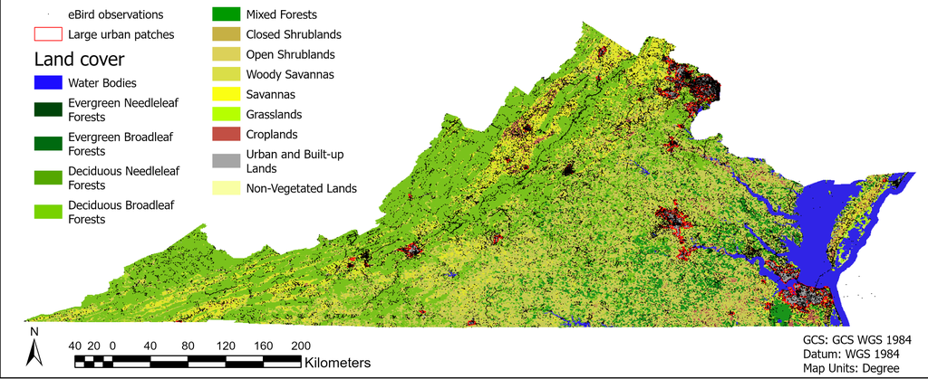

Figure 1.1: Land cover across Virginia, according to MCD12Q1.061 MODIS Land Cover Type Yearly Global data product, with eBird observations and large urban patches indicated.

```r
events_lc <- read_csv("./data/events_lc.csv") %>%
  select(SAMPLING_EVENT_IDENTIFIER, LATITUDE, LONGITUDE, is_urban, habitat, Id, src_area_km2)
```

### 1.3.4 Data preparation

For each large urban patch, a list of species that occur within an island should be constructed. To see what species are found outside of these patches and check whether such species colonized into the city, and to account for sampling effort within the patch, a pool of closest number of observations that have been collected within the patch is also pooled from outside (Fig. 1.2).

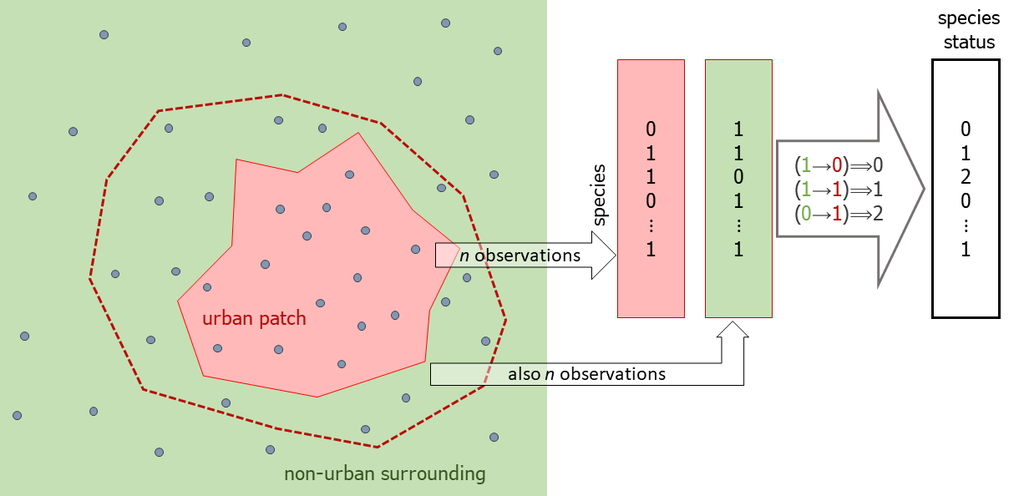

Figure 1.2: Pooling observations into those collected within and outside of the urban patches in a balanced way. The number of observations is maintained the same between the two groups to construct the species lists and assign species different statuses: 0 if the species that occurs out of the city does not colonize it, 1 if the species that occurs outside of the city is also observed in the city, 2 if the species occurs within the city but is not found outside.

Based on the presence/absence data for each species, it is classified into one of the categories explained in Table 1.1).

Table 1.1: Possible species statuses.

| Status | Explanation |
| --- | --- |
| 0 | species that occurs out of the city does not colonize that city |
| 1 | species that occurs outside of the city is also observed in the city |
| 2 | species occurs within the city but is not found outside |

```r
library(geosphere)
cities <- events_lc$Id %>% unique() %>% .[!is.na(.)]
find_closest_points <- function(cityid){
  urb_pool <- events_lc %>%
    filter(Id == cityid)
  n <- nrow(urb_pool)
  clat <- urb_pool$LATITUDE %>% mean()
  clon <- urb_pool$LONGITUDE %>% mean()
  calc_dist <- function(long, lat){
    sapply(1:length(long), function(i){
      geosphere::distHaversine(
      matrix(c(clon, clat, long[i], lat[i]), nrow = 2, ncol = 2, byrow = T),
      r = 6378.137)
    })
  }
  nonurb_pool <- events_lc %>%
    filter(is_urban == 0) %>%
    mutate(dist = calc_dist(LONGITUDE, LATITUDE)) %>%
    arrange(dist) %>%
    as_tibble() %>%
    .[1:n, ] %>%
    mutate(Id = cityid)
  return(nonurb_pool)
}
nonurb_pools <- find_closest_points(cities[1])
for (city in cities[-1]){
  nonurb_pools <- bind_rows(nonurb_pools,
                            find_closest_points(city))
} #takes ~ 8 minutes
write_csv(nonurb_pools, "./data/nonurb_pools.csv")
nonurb_pools <- read_csv("./data/nonurb_pools.csv")
```

Now there are two datasets with sampling event identifiers that can be called to obtain the species lists within and outside of the defined urban patches. I do not proceed to obtaining the lists here because there might be some considerable variation in sampling among the patches, which I look at in the next section.

# 2 Explanatory Data Analysis

## 2.1 Sampling effort among the urban patches

First, we will check how variable is the number of observation events per patch (Fig. 2.1-A) and whether it is related with the patch area (Fig. 2.1-B).

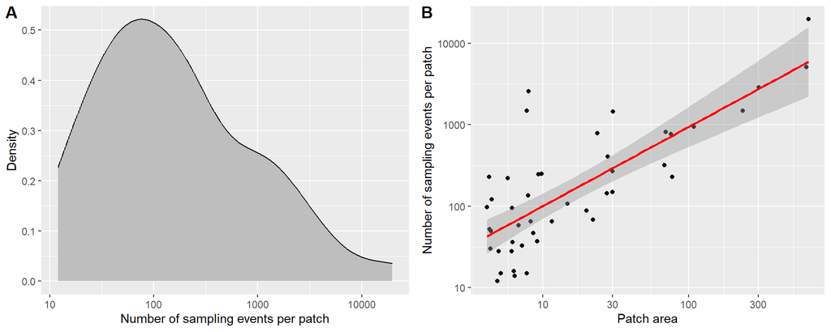

Figure 2.1: Distribution of sampling effort per patch and its relationship with patch area.

There seems to be a wide range of both:

```r
events_lc %>%
  filter(is_urban == 1) %>%
  group_by(Id) %>%
  summarise(n = n(), area = mean(src_area_km2)) %>%
  select(-Id) %>%
  summary()
```

```
##        n                area
##  Min.   :   12.0   Min.   :  4.150
##  1st Qu.:   47.0   1st Qu.:  6.162
##  Median :  122.0   Median :  8.600
##  Mean   :  927.4   Mean   : 58.679
##  3rd Qu.:  408.0   3rd Qu.: 29.982
##  Max.   :19687.0   Max.   :660.279
```

Therefore, it seems justified to parse the observations within the urban patches that have large numbers of observations into groups of 50 observations, which roughly corresponds to the 25th percentile of the number of sampling events per patch.

```r
parse_sampling <- function(dataset){
  n <- nrow(dataset)
  if (n >= 50){
    p <- sample(x = 1:(n%/%50), size = n, replace = T)
  }else{
    p <- rep(1, n)
  }
  dataset %>%
    mutate(parse = p)
}
parsed_events <- bind_rows(events_lc %>% filter(Id == cities[1]) %>% parse_sampling(),
                           nonurb_pools %>% filter(Id == cities[1]) %>% parse_sampling())
for (city in cities[-1]){
  parsed_events <- bind_rows(parsed_events,
                            events_lc %>% filter(Id == city) %>% parse_sampling(),
                            nonurb_pools %>% filter(Id == city) %>% parse_sampling())
}
write_csv(parsed_events, "./data/parsed_events.csv")
parsed_events <- read_csv("./data/parsed_events.csv")
parsed_events %>%
  distinct(Id, parse) %>% nrow()
```

```
## [1] 824
```

Overall, we partitioned the data into 824 units which have a similar sampling effort and can be used for the further analysis.

## 2.2 Pooling species lists

Now we can use the partitioned lists of sampling events to pools of species observed during those sampling events.

```r
draw_species_sed <- function(sed){
  brds %>%
    filter(`SAMPLING EVENT IDENTIFIER` %in% sed) %>%
    group_by(`TAXONOMIC ORDER`, `COMMON NAME`) %>%
    summarise(abundance = mean(`OBSERVATION COUNT`, na.rm = T),
              freq = n() / length(sed),
              .groups = "drop")
}
draw_species_pool <- function(pool, urban){
  pool <- pool %>% filter(is_urban == urban)
  draw_species_sed(pool$SAMPLING_EVENT_IDENTIFIER %>% unlist()) %>%
    mutate(is_urban = pool$is_urban[1], patch_id = pool$Id[1], parse = pool$parse[1])
}
parsed_species_lists <- tibble(NA)[0]
parsed_ids <- parsed_events %>% distinct(Id, parse) %>% as.matrix()
for (i in 1:nrow(parsed_ids)){
  parsed_species_lists <- bind_rows(parsed_species_lists,
                                    draw_species_pool(parsed_events %>%
                                                        filter(Id == parsed_ids[i, 1], parse == parsed_ids[i, 2]), urban = 0),
                                    draw_species_pool(parsed_events %>%
                                                        filter(Id == parsed_ids[i, 1], parse == parsed_ids[i, 2]), urban = 1))
}
write_csv(parsed_species_lists[-1,], "./data/parsed_species_lists.csv")
parsed_species_lists <- read_csv("./data/parsed_species_lists.csv")
```

## 2.3 Clean dataset

Finally, `parsed_species_lists` can be used to define the status of each species for each partition of urban patches, as it was shown in Fig. 1.2.

```r
assign_status <- function(nonurb, urb){
  nonurb <- nonurb %>%
    group_by(`COMMON NAME`) %>%
    summarise(`TAXONOMIC ORDER` = min(`TAXONOMIC ORDER`[`TAXONOMIC ORDER` %in% traits$ebd_id2022]),
              `COMMON NAME` = `COMMON NAME`[1],
              abundance = sum(abundance),
              freq = sum(freq),
              is_urban = is_urban[1],
              patch_id = patch_id[1],
              parse = parse[1])
  urb <- urb %>%
    group_by(`COMMON NAME`) %>%
    summarise(`TAXONOMIC ORDER` = min(`TAXONOMIC ORDER`[`TAXONOMIC ORDER` %in% traits$ebd_id2022]),
              `COMMON NAME` = `COMMON NAME`[1],
              abundance = sum(abundance),
              freq = sum(freq),
              is_urban = is_urban[1],
              patch_id = patch_id[1],
              parse = parse[1])
  compare <- full_join(nonurb, urb, by = "COMMON NAME", relationship = "one-to-one")
  compare[is.na(compare)] <- 0
  compare %>%
    mutate(status = ifelse(compare$abundance.x > 0 & compare$abundance.y == 0, 0,
                           ifelse(compare$abundance.x > 0 & compare$abundance.x > 0, 1,
                                  ifelse(compare$abundance.x == 0 & compare$abundance.y > 0, 2, 3))),
           dif_abundance = compare$abundance.x - compare$abundance.y,
           dif_freq = compare$freq.x - compare$freq.y,
           ebd_id2022 = apply(data.frame(compare$`TAXONOMIC ORDER.x`, compare$`TAXONOMIC ORDER.y`), 1, max),
           patch_id = apply(data.frame(compare$patch_id.x, compare$patch_id.y), 1, max),
           parse = apply(data.frame(compare$parse.x, compare$parse.y), 1, max),
           common_name = `COMMON NAME`) %>%
    select(common_name, ebd_id2022, patch_id, parse, status, dif_abundance, dif_freq)
}

parsed_species_statuses <- tibble(NA)[0]
parsed_ids <- parsed_events %>% distinct(Id, parse) %>% as.matrix()
for (i in 1:nrow(parsed_ids)){
  print(i)
  parsed_species_statuses <- bind_rows(parsed_species_statuses,
                                       assign_status(parsed_species_lists %>% filter(is_urban == 0,
                                                                           patch_id == parsed_ids[i, 1],
                                                                           parse == parsed_ids[i, 2]),
                                           parsed_species_lists %>% filter(is_urban == 1,
                                                                           patch_id == parsed_ids[i, 1],
                                                                           parse == parsed_ids[i, 2])))
}
parsed_species_statuses <- parsed_species_statuses[-1,]
write_csv(parsed_species_statuses, "./data/parsed_species_statuses.csv")
parsed_species_statuses %>%
  left_join(traits, by = "ebd_id2022") %>%
  filter(!is.na(hwi)) %>%
  write_csv(file = "./data/urb_brds.csv")
urb_brds <- read_csv("./data/urb_brds.csv")
```

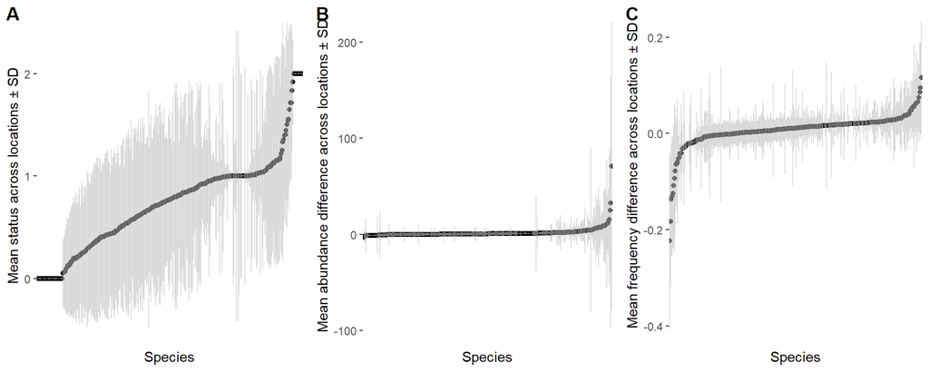

Figure 2.2: Variability of species statuses and differences in abundance and frequency across urban patches.

Although there is a significant correlation (Spearman’s $\rho = 0.438, p < 0.001$) between the difference in frequency and difference in abundance among the species, high significance can be explained by the large sample size, as visually there is no linear relationship between these two metrics (Fig. 2.3-A). The positive association between changes in abundance and changes in frequency only become visible when both metrics are transformed with a logistic function. Obviously, both change in abundance and frequency can only be positive for species with status “0” and negative for status “2” (Fig. 2.3-B,C). However, one can see that the variation of difference in abundance of species with status “1” is very high and overlaps with both “0” and “2” (Fig. 2.3-B).

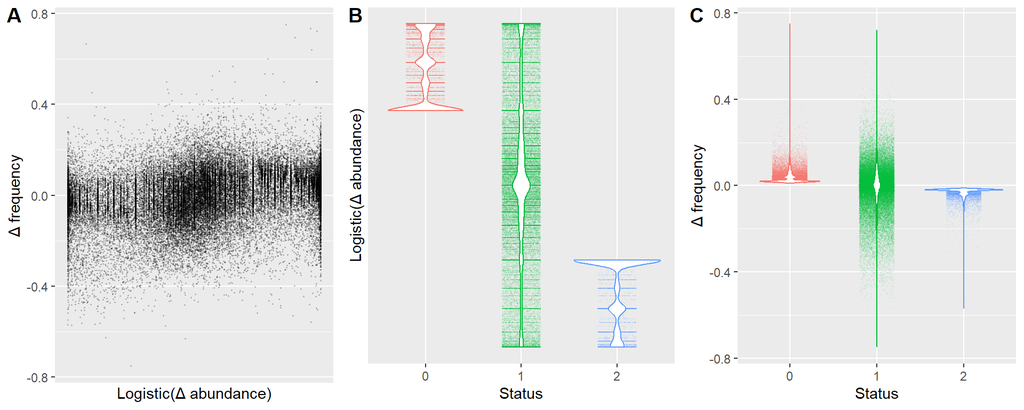

Figure 2.3: Covariation of species statuses and differences in abundance and frequency across urban patches.

# 3 Modeling and Methodology

To answer the different research questions, different methods should be deployed. Yet, these questions are interconnected to some extent. For example, finding the traits that determine environmental filtering and modeling whether a species can successfully establish a viable population within a city based on species traits manifest different sides of the same model, where species success within urban habitats is explained by combinations of traits (i.e., species descriptors).

For all models in the further analysis, the dataset should be divided into training and test datasets for model building and validation respectively. Luckily, there are more than enough observations to split it into two equal datasets with large amounts of data.

```r
set.seed(1)
idx <- sample(x = 1:2, size = nrow(urb_brds), replace = T)
urb_brds_train <- urb_brds[idx == 1,]
urb_brds_test <- urb_brds[idx == 2,]
```

## 3.1 Finding the meaningful traits via dimension reduction

For this section, difference of abundance and difference of frequency of species outside and within an urban patch will be used as a continuous response variable in a model. The main purpose of this section is to reveal species traits that are relevant to environmental filtering and, thus, can predict occurrence of species in urban patches, especially given that it has already been shown that differences of abundance and frequency can be used as proxy to the status of species (Fig. 2.3).

### 3.1.1 Lasso regression

Using lasso regression, one may determine which predictors contribute poorly to the model, as the model will minimize the error function in such a way as it will set some coefficients to 0. In the setting presented here, one may then conclude that those traits for which coefficients are set to 0 are irrelevant to environmental filtering. First, the optimal tuning parameter $\lambda$ has to be found.

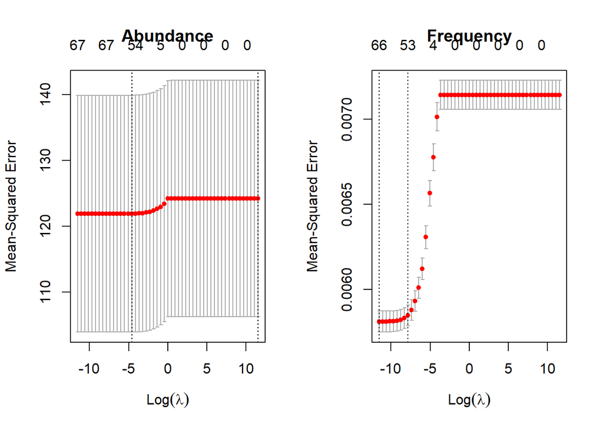

```r
library(glmnet)
lambda_cands <- 10^seq(-5, 5, by = 0.2)
x <- urb_brds_train[,c("hwi", "mlife", "adsurviv", "matage", "parasi", "egglow", "eggupp",
                 "suces", "attem", "bmass", "naggr", "ndepen",
                 "nsbank", "nsgroun", "nsgrass", "nsclif", "nsbuild", "nsshru",
                 "nsdeci", "nsconi", "nssnag", "nscact", "nstang", "nsfloat",
                 "fsmud", "fswatb", "fswata", "fstimb", "fsgroun", "fsunder",
                 "fsmidhigh", "fscanopy", "fsaerial", "fsdump",
                 "fpnoct", "fpdiur", "klepto",
                 "fcinvert", "fcvend", "fcvect", "fcfish", "fcunk", "fcscav", "fcfruit",
                 "fcnect", "fcseed", "fcgree", "fcleft",
                 "fmdig", "fmgrgl", "fmfogl", "fmbagl", "fmhogl", "fmhopo", "fmhawk", "fmaero", "fmapur",
                 "fmswoo", "fmhipa", "fmlopa", "fmhidi", "fmskim", "fmsdiv", "fmsdip", "fmdabb",
                 "fmstal", "fmprob")] %>% as.data.frame()
y_a <- urb_brds_train$dif_abundance %>% unlist()
y_f <- urb_brds_train$dif_freq %>% unlist()
cv_llm_a <- cv.glmnet(as.matrix(x), y_a, alpha = 1, lambda = lambda_cands, nfolds = 10)
cv_llm_f <- cv.glmnet(as.matrix(x), y_f, alpha = 1, lambda = lambda_cands, nfolds = 10)
par(mfrow = c(1, 2))
plot(cv_llm_a, main = "Abundance")
plot(cv_llm_f, main = "Frequency")
```

Both plots suggest that the optimal $\lambda$s are low, which implies that the lasso models will be close to the least-squares regression.

```r
set.seed(1)
lasso_best_lambdas <- c("lambda_a" = cv_llm_a$lambda[which(cv_llm_a$cvm == min(cv_llm_a$cvm))],
  "lambda_f" = cv_llm_f$lambda[which(cv_llm_f$cvm == min(cv_llm_f$cvm))])
llm_a <- glmnet(as.matrix(x), y_a, alpha = 1, lambda = lasso_best_lambdas["lambda_a"], standardize = T)
llm_f <- glmnet(as.matrix(x), y_f, alpha = 1, lambda = lasso_best_lambdas["lambda_f"], standardize = T)
llms_coefs <- data.frame(llm_a = as.matrix(llm_a$beta), llm_f = as.matrix(llm_f$beta))
llms_coefs[llms_coefs == 0] <- NA
colnames(llms_coefs) <- c("Abundance", "Frequency")
llms_coefs
```

```
##               Abundance     Frequency
## hwi        0.0165026489 -6.682965e-05
## mlife     -0.0052084362 -3.152374e-03
## adsurviv   0.9066253931  3.626375e-02
## matage     0.1238522810  6.474330e-03
## parasi     0.4861472593  1.685712e-02
## egglow               NA -2.581069e-03
## eggupp    -0.1053157130  3.059392e-04
## suces      1.1220229874  4.411215e-02
## attem     -0.2051689532  3.399692e-03
## bmass     -0.0001335687  1.099760e-06
## naggr      1.1705021272 -4.391706e-03
## ndepen    -0.1794056674  2.171219e-02
## nsbank    -0.0083725530 -8.344664e-04
## nsgroun    0.0001154206  2.993082e-04
## nsgrass    0.0050451339  1.988093e-04
## nsclif     0.0487307097  7.019734e-04
## nsbuild   -0.0121290340 -9.039809e-04
## nsshru               NA  1.582314e-04
## nsdeci    -0.0054490166 -8.788119e-05
## nsconi               NA -1.126683e-04
## nssnag    -0.0049898502  2.893078e-04
## nscact     0.0714323602 -2.808824e-03
## nstang     0.0032088807 -8.100160e-06
## nsfloat   -0.0195213308  3.163998e-05
## fsmud                NA  4.056143e-04
## fswatb     0.0110468767  4.689349e-04
## fswata    -0.0004694035  6.086329e-04
## fstimb    -0.0082181549 -1.119174e-04
## fsgroun    0.0036332230  4.403424e-04
## fsunder              NA -2.418152e-04
## fsmidhigh -0.0068279331 -1.599870e-04
## fscanopy   0.0056292945 -4.018925e-06
## fsaerial  -0.0252805518  2.223060e-04
## fsdump    -0.1060262794 -2.536303e-03
## fpnoct    -0.5764995716  3.954379e-03
## fpdiur    -1.2940704161  9.689733e-02
## klepto     4.8244181277  4.301360e-02
## fcinvert   0.0044450026  1.418004e-04
## fcvend     0.0058998161 -1.129047e-04
```

[output cut: 13 more lines]

```
## fmhogl    -0.0018372139  3.944580e-04
## fmhopo    -0.0047522070 -5.778289e-04
## fmhawk               NA  7.444485e-04
## fmaero               NA  4.504658e-04
## fmapur    -0.0144518568  1.689456e-04
## fmswoo    -0.0018662912  3.066572e-04
## fmhipa    -0.0095820550  4.059925e-04
## fmlopa               NA  4.877246e-05
## fmhidi     0.0011913680  1.616497e-04
## fmskim    -0.0409164613 -5.437085e-04
## fmsdiv     0.0305863785 -4.247600e-04
## fmsdip     0.0312012033 -4.903891e-04
## fmdabb    -0.0139386132 -4.894345e-04
## fmstal    -0.0189769363 -2.032930e-04
## fmprob     0.0196231439 -5.220752e-04
```

Indeed, there are very few coefficients that are excluded from the model. Given how many predictors are in the whole set of `x`, one could expect that several predictors will be excluded just due to a random chance, which implies that both of the models say little about relevant functional traits.

### 3.1.2 Principal component analysis regression

The variety of birds traits used (Table 6.1) suggest that there is some redundancy in them. Indeed, biologically, one could predict that traits like `fc_categ` (diet category with levels: `FruiNect`, `Invertebrate`, `Omnivore`, `PlantSeed`, `VertFishScav`) will covary with variables of distribution of diet items (e.g., `FruiNect` will be positively associated with `fcfruit`, `fcnect`, `fcseed`, etc.) Moreover, it can be expected that different traits are related, for example, feeding method and diet items (e.g., it would be unlikely that a species that primarily consumes nectar and green part of plants obtains the food through high gliding and aerial pursuit or finds the food items in the air rather than on trees and in canopy). Therefore, there should be utility in dimension reduction that would account for high covariation between some variables.

```r
set.seed(1)
library(pls)
pcr_a_all <- pls::pcr(y_a ~ ., data = cbind(y_a, x), scale = T, validation = "CV")
pcr_f_all <- pls::pcr(y_f ~ ., data = cbind(y_f, x), scale = T, validation = "CV")
```

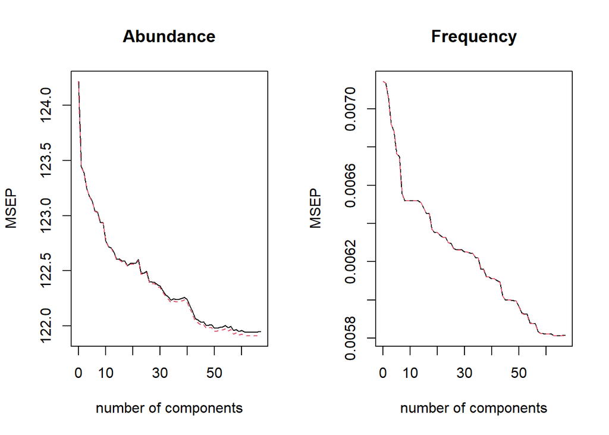

```r
par(mfrow = c(1, 2))
validationplot(pcr_a_all, val.type = "MSEP", main = "Abundance")
validationplot(pcr_f_all, val.type = "MSEP", main = "Frequency")
```

The validation plots suggest that the expectations do not reflect reality and few principal components cannot explain the variance of difference of either abundance or frequency of species.

```r
summary(pcr_a_all)
```

```
## Data:    X dimension: 48733 67
##  Y dimension: 48733 1
## Fit method: svdpc
## Number of components considered: 67
##
## VALIDATION: RMSEP
## Cross-validated using 10 random segments.
##        (Intercept)  1 comps  2 comps  3 comps  4 comps  5 comps  6 comps
## CV           11.15    11.11    11.11     11.1     11.1     11.1    11.09
## adjCV        11.15    11.11    11.11     11.1     11.1     11.1    11.09
##        7 comps  8 comps  9 comps  10 comps  11 comps  12 comps  13 comps
## CV       11.09    11.09    11.09     11.08     11.08     11.08     11.08
## adjCV    11.09    11.09    11.09     11.08     11.08     11.08     11.08
##        14 comps  15 comps  16 comps  17 comps  18 comps  19 comps  20 comps
## CV        11.07     11.07     11.07     11.07     11.07     11.07     11.07
## adjCV     11.07     11.07     11.07     11.07     11.07     11.07     11.07
##        21 comps  22 comps  23 comps  24 comps  25 comps  26 comps  27 comps
## CV        11.07     11.07     11.07     11.07     11.07     11.06     11.06
## adjCV     11.07     11.07     11.07     11.07     11.07     11.06     11.06
##        28 comps  29 comps  30 comps  31 comps  32 comps  33 comps  34 comps
## CV        11.06     11.06     11.06     11.06     11.06     11.06     11.06
## adjCV     11.06     11.06     11.06     11.06     11.06     11.06     11.06
##        35 comps  36 comps  37 comps  38 comps  39 comps  40 comps  41 comps
## CV        11.06     11.06     11.06     11.06     11.06     11.06     11.05
## adjCV     11.06     11.06     11.06     11.06     11.06     11.06     11.05
##        42 comps  43 comps  44 comps  45 comps  46 comps  47 comps  48 comps
## CV        11.05     11.05     11.05     11.05     11.05     11.05     11.05
## adjCV     11.05     11.05     11.05     11.05     11.05     11.04     11.04
##        49 comps  50 comps  51 comps  52 comps  53 comps  54 comps  55 comps
## CV        11.05     11.04     11.04     11.04     11.05     11.05     11.04
## adjCV     11.04     11.04     11.04     11.04     11.04     11.04     11.04
##        56 comps  57 comps  58 comps  59 comps  60 comps  61 comps  62 comps
## CV        11.05     11.04     11.04     11.04     11.04     11.04     11.04
## adjCV     11.04     11.04     11.04     11.04     11.04     11.04     11.04
##        63 comps  64 comps  65 comps  66 comps  67 comps
## CV        11.04     11.04     11.04     11.04     11.04
## adjCV     11.04     11.04     11.04     11.04     11.04
##
## TRAINING: % variance explained
##      1 comps  2 comps  3 comps  4 comps  5 comps  6 comps  7 comps  8 comps
```

[output cut: 14 more lines]

```
##      37 comps  38 comps  39 comps  40 comps  41 comps  42 comps  43 comps
## X      91.467    92.192    92.904    93.546    94.160    94.723    95.261
## y_a     1.899     1.899     1.899     1.918     1.967     2.017     2.074
##      44 comps  45 comps  46 comps  47 comps  48 comps  49 comps  50 comps
## X      95.752    96.192    96.622    97.031    97.417    97.766    98.086
## y_a     2.087     2.112     2.118     2.158     2.164     2.167     2.205
##      51 comps  52 comps  53 comps  54 comps  55 comps  56 comps  57 comps
## X      98.381    98.630    98.868    99.057    99.224    99.389    99.523
## y_a     2.205     2.223     2.223     2.227     2.254     2.264     2.296
##      58 comps  59 comps  60 comps  61 comps  62 comps  63 comps  64 comps
## X      99.653    99.761    99.846    99.924    99.965   100.000   100.000
## y_a     2.297     2.314     2.314     2.327     2.336     2.337     2.338
##      65 comps  66 comps  67 comps
## X     100.000   100.000   100.000
## y_a     2.338     2.339     2.339
```

PCR cannot be used for variable selection *per se*. However, loadings of variables reflect contribution of these variables to the principal components, which can be used to draw inference about relative importance of different traits. By default, `pls::pcr()$loadings` does not print some loadings, and in `?stats::loadings` we see that “Small loadings are conventionally not printed (replaced by spaces), to draw the eye to the pattern of the larger loadings.” It is unclear, though, what loading value is small enough to be neglected. [Here](https://imaging.mrc-cbu.cam.ac.uk/statswiki/FAQ/thresholds) we read: “… Field (2005) advocates the suggestion of Guadagnoli & Velicer (1988) to regard a factor as reliable if it has four or more loadings of at least 0.6 regardless of sample size. Stevens (1992) suggests using a cut-off of 0.4, irrespective of sample size, for interpretative purposes.” (Guadagnoli and Velicer 1988, Stevens 1992, Field 2005)

```r
pcr_a <- pcr(y_a ~ ., data = cbind(y_a, x), scale = T, ncomp = 36)
pcr_a_l <- pcr_a$loadings
pcr_a_l <- data.frame(matrix(as.numeric(pcr_a_l), attributes(pcr_a_l)$dim, dimnames = attributes(pcr_a_l)$dimnames))
pcr_a_l_large <- apply(pcr_a_l, 1, function(x) sum(abs(x)>= 0.4))
names(pcr_a_l_large)[pcr_a_l_large != 0]
```

```
##  [1] "suces"    "nsdeci"   "nscact"   "nstang"   "fsaerial" "fpdiur"
##  [7] "fcunk"    "fcnect"   "fmdig"    "fmaero"   "fmapur"   "fmskim"
## [13] "fmsdip"
```

From this we can argue that nesting success, nesting on certain substrates (deciduous trees, cacti, tangles), feeding in air, being diurnal, having certain diet (vertebrates or nectar) and methods of feeding (digging, aerial foliage, aerial pursuit, skimming or dipping) are the traits that affect changes of species abundance along an urban gradient.

Similarly, for changes in frequency,

```r
summary(pcr_f_all)
```

```
## Data:    X dimension: 48733 67
##  Y dimension: 48733 1
## Fit method: svdpc
## Number of components considered: 67
##
## VALIDATION: RMSEP
## Cross-validated using 10 random segments.
##        (Intercept)  1 comps  2 comps  3 comps  4 comps  5 comps  6 comps
## CV         0.08452  0.08447    0.084  0.08318  0.08297  0.08225  0.08216
## adjCV      0.08452  0.08447    0.084  0.08318  0.08297  0.08225  0.08216
##        7 comps  8 comps  9 comps  10 comps  11 comps  12 comps  13 comps
## CV     0.08097  0.08074  0.08074   0.08074   0.08074   0.08074   0.08073
## adjCV  0.08097  0.08074  0.08074   0.08073   0.08074   0.08074   0.08073
##        14 comps  15 comps  16 comps  17 comps  18 comps  19 comps  20 comps
## CV      0.08068    0.0805   0.08033   0.08032   0.07981    0.0797    0.0797
## adjCV   0.08068    0.0805   0.08033   0.08032   0.07980    0.0797    0.0797
##        21 comps  22 comps  23 comps  24 comps  25 comps  26 comps  27 comps
## CV      0.07961   0.07956   0.07954   0.07938   0.07934   0.07918   0.07913
## adjCV   0.07961   0.07956   0.07954   0.07938   0.07934   0.07917   0.07913
##        28 comps  29 comps  30 comps  31 comps  32 comps  33 comps  34 comps
## CV      0.07913   0.07913   0.07906   0.07906   0.07903   0.07902   0.07888
## adjCV   0.07913   0.07913   0.07906   0.07906   0.07902   0.07902   0.07887
##        35 comps  36 comps  37 comps  38 comps  39 comps  40 comps  41 comps
## CV      0.07886   0.07849   0.07849   0.07825   0.07823   0.07818   0.07817
## adjCV   0.07886   0.07848   0.07848   0.07824   0.07823   0.07817   0.07817
##        42 comps  43 comps  44 comps  45 comps  46 comps  47 comps  48 comps
## CV      0.07811   0.07806   0.07760   0.07746   0.07746   0.07746   0.07744
## adjCV   0.07810   0.07806   0.07759   0.07746   0.07746   0.07746   0.07743
##        49 comps  50 comps  51 comps  52 comps  53 comps  54 comps  55 comps
## CV      0.07742   0.07724   0.07702   0.07698   0.07698   0.07668   0.07666
## adjCV   0.07742   0.07723   0.07702   0.07697   0.07697   0.07668   0.07665
##        56 comps  57 comps  58 comps  59 comps  60 comps  61 comps  62 comps
## CV      0.07666    0.0764   0.07632   0.07632    0.0763    0.0763    0.0763
## adjCV   0.07665    0.0764   0.07632   0.07631    0.0763    0.0763    0.0763
##        63 comps  64 comps  65 comps  66 comps  67 comps
## CV      0.07624   0.07624   0.07625   0.07625   0.07625
## adjCV   0.07624   0.07624   0.07624   0.07624   0.07624
##
## TRAINING: % variance explained
##      1 comps  2 comps  3 comps  4 comps  5 comps  6 comps  7 comps  8 comps
```

[output cut: 14 more lines]

```
##      37 comps  38 comps  39 comps  40 comps  41 comps  42 comps  43 comps
## X       91.47     92.19     92.90     93.55     94.16     94.72     95.26
## y_f     13.87     14.39     14.44     14.56     14.57     14.72     14.82
##      44 comps  45 comps  46 comps  47 comps  48 comps  49 comps  50 comps
## X       95.75     96.19     96.62     97.03     97.42     97.77     98.09
## y_f     15.83     16.12     16.12     16.13     16.19     16.22     16.62
##      51 comps  52 comps  53 comps  54 comps  55 comps  56 comps  57 comps
## X       98.38     98.63     98.87     99.06     99.22     99.39     99.52
## y_f     17.10     17.20     17.20     17.83     17.89     17.90     18.45
##      58 comps  59 comps  60 comps  61 comps  62 comps  63 comps  64 comps
## X       99.65     99.76     99.85     99.92     99.97    100.00    100.00
## y_f     18.63     18.64     18.68     18.68     18.68     18.82     18.82
##      65 comps  66 comps  67 comps
## X      100.00    100.00    100.00
## y_f     18.82     18.82     18.82
```

```r
pcr_f <- pcr(y_f ~ ., data = cbind(y_f, x), scale = T, ncomp = 36)
pcr_f_l <- pcr_f$loadings
pcr_f_l <- data.frame(matrix(as.numeric(pcr_f_l), attributes(pcr_f_l)$dim, dimnames = attributes(pcr_f_l)$dimnames))
pcr_f_l_large <- apply(pcr_f_l, 1, function(x) sum(abs(x)>= 0.4))
names(pcr_f_l_large)[pcr_f_l_large != 0]
```

```
##  [1] "suces"    "nsdeci"   "nscact"   "nstang"   "fsaerial" "fpdiur"
##  [7] "fcunk"    "fcnect"   "fmdig"    "fmaero"   "fmapur"   "fmskim"
## [13] "fmsdip"
```

Not surprisingly, the traits selected as the most important are the same as for difference in abundance.

The way these models were considered, they are suitable for predictions but say little about the effect of variables (thus, specific principal components) on the response variable. Yet, with the dataset presented here, several assumptions of the linear model might be broken[^13].

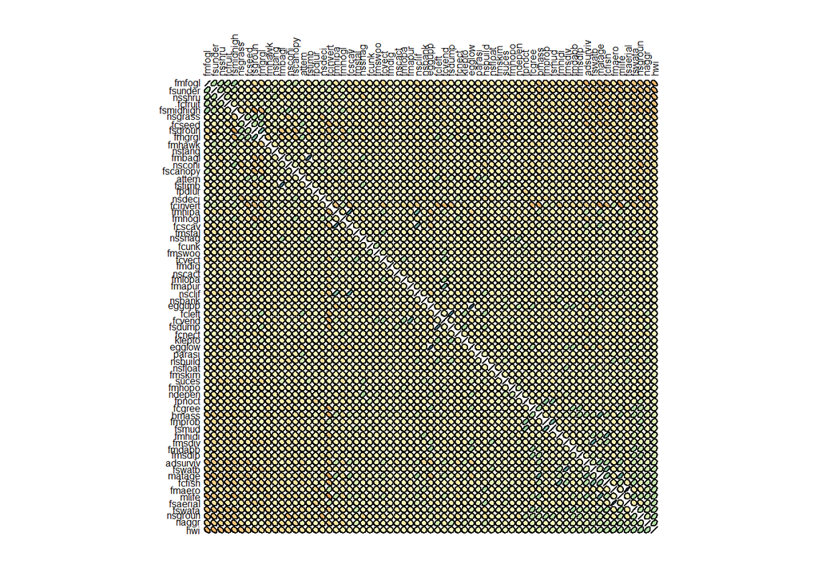

```r
library(ellipse)
library(RColorBrewer)
plotcorr(cor(x)[order(cor(x)[1, ]), order(cor(x)[1, ])],
         col = colorRampPalette(brewer.pal(5, "Spectral"))(100)[cor(x)[order(cor(x)[1, ]), order(cor(x)[1, ])]*50+50],
         mar=c(1,1,1,1), cex.lab = 0.5)
```

### 3.1.3 Partial least squares regression

I will follow the same template as in the previous section.

```r
set.seed(1)
pls_a_all <- pls::plsr(y_a ~ ., data = cbind(y_a, x), scale = T, validation = "CV")
pls_f_all <- pls::plsr(y_f ~ ., data = cbind(y_f, x), scale = T, validation = "CV")
```

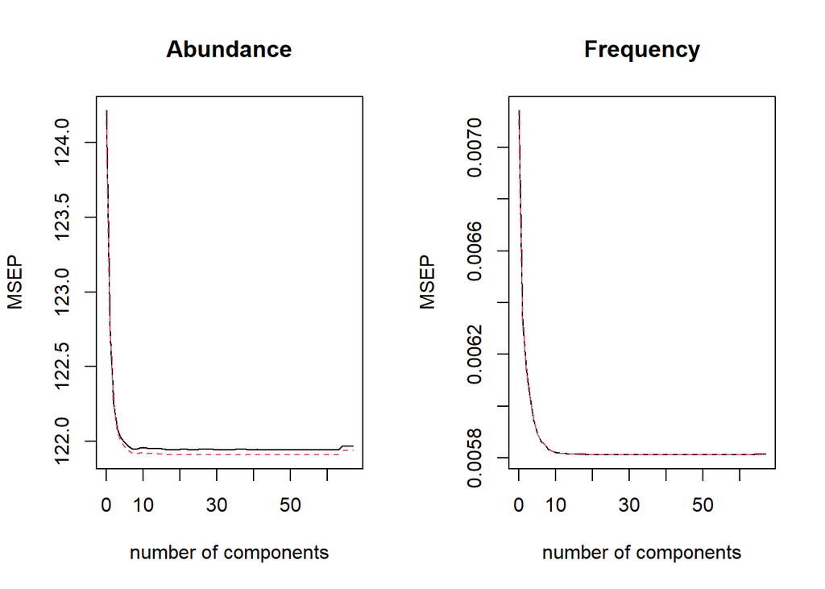

```r
par(mfrow = c(1, 2))
validationplot(pls_a_all, val.type = "MSEP", main = "Abundance")
validationplot(pls_f_all, val.type = "MSEP", main = "Frequency")
```

However, PLSR’s cross-validation errors suggest that there is only few components that suffice to predict differences in species abundance:

```r
MSEP(pls_a_all)
```

```
##        (Intercept)  1 comps  2 comps  3 comps  4 comps  5 comps  6 comps
## CV           124.2    122.7    122.2    122.1      122      122    122.0
## adjCV        124.2    122.7    122.2    122.1      122      122    121.9
##        7 comps  8 comps  9 comps  10 comps  11 comps  12 comps  13 comps
## CV       122.0    121.9    122.0     122.0     122.0     122.0     121.9
## adjCV    121.9    121.9    121.9     121.9     121.9     121.9     121.9
##        14 comps  15 comps  16 comps  17 comps  18 comps  19 comps  20 comps
## CV        122.0     121.9     121.9     121.9     121.9     121.9     121.9
## adjCV     121.9     121.9     121.9     121.9     121.9     121.9     121.9
##        21 comps  22 comps  23 comps  24 comps  25 comps  26 comps  27 comps
## CV        121.9     121.9     121.9     121.9     121.9     121.9     121.9
## adjCV     121.9     121.9     121.9     121.9     121.9     121.9     121.9
##        28 comps  29 comps  30 comps  31 comps  32 comps  33 comps  34 comps
## CV        121.9     121.9     121.9     121.9     121.9     121.9     121.9
## adjCV     121.9     121.9     121.9     121.9     121.9     121.9     121.9
##        35 comps  36 comps  37 comps  38 comps  39 comps  40 comps  41 comps
## CV        121.9     121.9     121.9     121.9     121.9     121.9     121.9
## adjCV     121.9     121.9     121.9     121.9     121.9     121.9     121.9
##        42 comps  43 comps  44 comps  45 comps  46 comps  47 comps  48 comps
## CV        121.9     121.9     121.9     121.9     121.9     121.9     121.9
## adjCV     121.9     121.9     121.9     121.9     121.9     121.9     121.9
##        49 comps  50 comps  51 comps  52 comps  53 comps  54 comps  55 comps
## CV        121.9     121.9     121.9     121.9     121.9     121.9     121.9
## adjCV     121.9     121.9     121.9     121.9     121.9     121.9     121.9
##        56 comps  57 comps  58 comps  59 comps  60 comps  61 comps  62 comps
## CV        121.9     121.9     121.9     121.9     121.9     121.9     121.9
## adjCV     121.9     121.9     121.9     121.9     121.9     121.9     121.9
##        63 comps  64 comps  65 comps  66 comps  67 comps
## CV        121.9     122.0     122.0     122.0     122.0
## adjCV     121.9     121.9     121.9     121.9     121.9
```

In this model, we can observe that $\text{MSEP} \rightarrow 121.9$ at $M = 15$, which we will use in the subsequent analysis.

```r
pls_a <- plsr(y_a ~ ., data = cbind(y_a, x), scale = T, ncomp = 15)
pls_a_l <- pls_a$loadings
pls_a_l <- data.frame(matrix(as.numeric(pls_a_l), attributes(pls_a_l)$dim, dimnames = attributes(pls_a_l)$dimnames))
pls_a_l_large <- apply(pls_a_l, 1, function(x) sum(abs(x)>= 0.4))
names(pls_a_l_large)[pls_a_l_large != 0]
```

```
##  [1] "nsconi"   "nscact"   "fsmud"    "fsgroun"  "fsaerial" "fsdump"
##  [7] "fpnoct"   "fmgrgl"   "fmaero"   "fmprob"
```

These results are different from PCR. They suggest that trait variance within such traits as nest substrate (coniferous trees, cacti), feeding substrate (mud, ground, air, dumps), feeding time (nigh), and methods (ground glean, aerial foliage, probing) are sufficient to predict whether a species will have a different abundance within and outside of cities.

Now, we repeat for species frequencies.

```r
MSEP(pls_f_all)
```

```
##        (Intercept)   1 comps   2 comps   3 comps   4 comps   5 comps   6 comps
## CV        0.007143  0.006339  0.006148  0.006037  0.005947  0.005897  0.005865
## adjCV     0.007143  0.006339  0.006148  0.006036  0.005947  0.005896  0.005865
##         7 comps   8 comps   9 comps  10 comps  11 comps  12 comps  13 comps
## CV     0.005853  0.005834  0.005828  0.005822  0.005820  0.005818  0.005817
## adjCV  0.005852  0.005834  0.005827  0.005822  0.005819  0.005817  0.005816
##        14 comps  15 comps  16 comps  17 comps  18 comps  19 comps  20 comps
## CV     0.005816  0.005815  0.005815  0.005814  0.005814  0.005814  0.005813
## adjCV  0.005815  0.005815  0.005814  0.005814  0.005813  0.005813  0.005813
##        21 comps  22 comps  23 comps  24 comps  25 comps  26 comps  27 comps
## CV     0.005813  0.005813  0.005813  0.005813  0.005813  0.005813  0.005813
## adjCV  0.005813  0.005812  0.005812  0.005812  0.005812  0.005812  0.005812
##        28 comps  29 comps  30 comps  31 comps  32 comps  33 comps  34 comps
## CV     0.005813  0.005813  0.005813  0.005813  0.005813  0.005813  0.005813
## adjCV  0.005812  0.005812  0.005812  0.005812  0.005812  0.005812  0.005812
##        35 comps  36 comps  37 comps  38 comps  39 comps  40 comps  41 comps
## CV     0.005813  0.005813  0.005813  0.005813  0.005813  0.005813  0.005813
## adjCV  0.005812  0.005812  0.005812  0.005812  0.005812  0.005812  0.005812
##        42 comps  43 comps  44 comps  45 comps  46 comps  47 comps  48 comps
## CV     0.005813  0.005813  0.005813  0.005813  0.005813  0.005813  0.005813
## adjCV  0.005812  0.005812  0.005812  0.005812  0.005812  0.005812  0.005812
##        49 comps  50 comps  51 comps  52 comps  53 comps  54 comps  55 comps
## CV     0.005813  0.005813  0.005813  0.005813  0.005813  0.005813  0.005813
## adjCV  0.005812  0.005812  0.005812  0.005812  0.005812  0.005812  0.005812
##        56 comps  57 comps  58 comps  59 comps  60 comps  61 comps  62 comps
## CV     0.005813  0.005813  0.005813  0.005813  0.005813  0.005813  0.005813
## adjCV  0.005812  0.005812  0.005812  0.005812  0.005812  0.005812  0.005812
##        63 comps  64 comps  65 comps  66 comps  67 comps
## CV     0.005813  0.005814  0.005814  0.005814  0.005814
## adjCV  0.005812  0.005813  0.005813  0.005813  0.005813
```

Now, we see that $\text{MSEP} \rightarrow 5.813 \cdot 10^{-3}$ at $M = 20$.

```r
pls_f <- plsr(y_f ~ ., data = cbind(y_f, x), scale = T, ncomp = 20)
pls_f_l <- pls_f$loadings
pls_f_l <- data.frame(matrix(as.numeric(pls_f_l), attributes(pls_f_l)$dim, dimnames = attributes(pls_f_l)$dimnames))
pls_f_l_large <- apply(pls_f_l, 1, function(x) sum(abs(x)>= 0.4))
names(pls_f_l_large)[pls_f_l_large != 0]
```

```
##  [1] "parasi"   "suces"    "nsgrass"  "nsclif"   "nssnag"   "fsmud"
##  [7] "fstimb"   "fsaerial" "fcvend"   "fcfish"   "fcgree"   "fcleft"
## [13] "fmbagl"   "fmaero"   "fmhipa"   "fmdabb"
```

Unlike PCR, where modeling both difference of abundance and frequency of species yielded the same results, PLSR suggests that different traits determine shift of abundance and frequency. In the latter case, governing are the following: nest parasitism, nest success, nest substrate (grass, cliffs, snags), feeding substrate (mud, timber, air), diet items (warm-blooded vertebrates, fish, green parts of vegetation, human leftovers), and feeding methods (aerial foliage, high patrol, and dabbing).

### 3.1.4 Logistic regression

Although the logistic link function can be used in multi-level setting, I want to use it to model a canonical binary response[^14].

```r
# library(lme4)
y_a_bin <- y_a > 0
y_f_bin <- y_f > 0
logit_a <- glm(y_a_bin ~ ., data = cbind(y_a_bin, x), family = binomial)
logit_f <- glm(y_f_bin ~ ., data = cbind(y_f_bin, x), family = binomial)
# x_patch <- urb_brds_train$patch_id %>% unlist()
# x_parse <- urb_brds_train$parse %>% unlist()
# logitm_a <- glmer(y_a_bin ~ as.matrix(x) + (1+1|x_patch) + (1+1|x_parse), family = binomial)
# logitm_f <- glmer(y_f_bin ~ as.matrix(x) + (1+1|x_patch) + (1+1|x_parse), family = binomial)
```

```r
summary(logit_a)
```

```
##
## Call:
## glm(formula = y_a_bin ~ ., family = binomial, data = cbind(y_a_bin,
##     x))
##
## Deviance Residuals:
##     Min       1Q   Median       3Q      Max
## -1.9819  -1.2096   0.8235   1.0710   1.7085
##
## Coefficients: (4 not defined because of singularities)
##               Estimate Std. Error z value Pr(>|z|)
## (Intercept) -2.555e+00  5.037e-01  -5.072 3.95e-07 ***
## hwi          1.112e-02  1.808e-03   6.152 7.65e-10 ***
## mlife       -3.861e-02  3.037e-03 -12.711  < 2e-16 ***
## adsurviv     4.577e-01  1.124e-01   4.073 4.65e-05 ***
## matage      -5.190e-02  2.828e-02  -1.835 0.066472 .
## parasi       1.291e-01  8.705e-02   1.483 0.137973
## egglow      -1.579e-02  1.692e-02  -0.933 0.350707
## eggupp      -1.997e-02  1.287e-02  -1.551 0.120899
## suces       -1.563e-01  8.380e-02  -1.866 0.062080 .
## attem        5.507e-02  1.915e-02   2.876 0.004034 **
## bmass        6.516e-05  1.703e-05   3.826 0.000130 ***
## naggr        5.532e-02  2.498e-02   2.214 0.026812 *
## ndepen       6.201e-02  6.760e-02   0.917 0.358994
## nsbank      -6.524e-03  1.633e-03  -3.994 6.49e-05 ***
## nsgroun      5.587e-03  1.055e-03   5.296 1.18e-07 ***
## nsgrass      8.745e-03  1.159e-03   7.547 4.44e-14 ***
## nsclif       8.943e-03  2.231e-03   4.009 6.10e-05 ***
## nsbuild     -5.974e-03  1.322e-03  -4.518 6.25e-06 ***
## nsshru       4.636e-03  1.133e-03   4.091 4.29e-05 ***
## nsdeci       3.223e-03  1.133e-03   2.845 0.004437 **
## nsconi       2.051e-03  1.092e-03   1.879 0.060271 .
## nssnag       6.632e-03  1.227e-03   5.403 6.54e-08 ***
## nscact       1.636e-02  4.313e-03   3.792 0.000149 ***
## nstang       8.906e-03  3.228e-03   2.759 0.005805 **
## nsfloat             NA         NA      NA       NA
## fsmud       -7.079e-04  5.836e-03  -0.121 0.903450
## fswatb       1.327e-02  5.579e-03   2.378 0.017407 *
## fswata       1.119e-02  5.573e-03   2.009 0.044589 *
## fstimb      -8.589e-03  5.689e-03  -1.510 0.131128
```

[output cut: 34 more lines]

```
## fmsdiv      -8.459e-03  1.876e-03  -4.510 6.48e-06 ***
## fmsdip      -1.497e-02  2.091e-03  -7.156 8.28e-13 ***
## fmdabb      -1.326e-02  1.806e-03  -7.339 2.15e-13 ***
## fmstal      -1.159e-02  1.678e-03  -6.911 4.82e-12 ***
## fmprob              NA         NA      NA       NA
## ---
## Signif. codes:  0 '***' 0.001 '**' 0.01 '*' 0.05 '.' 0.1 ' ' 1
##
## (Dispersion parameter for binomial family taken to be 1)
##
##     Null deviance: 66712  on 48732  degrees of freedom
## Residual deviance: 64400  on 48669  degrees of freedom
## AIC: 64528
##
## Number of Fisher Scoring iterations: 4
```

```r
summary(logit_f)
```

```
##
## Call:
## glm(formula = y_f_bin ~ ., family = binomial, data = cbind(y_f_bin,
##     x))
##
## Deviance Residuals:
##     Min       1Q   Median       3Q      Max
## -2.2542  -1.2322   0.7651   0.9932   1.9318
##
## Coefficients: (4 not defined because of singularities)
##               Estimate Std. Error z value Pr(>|z|)
## (Intercept) -2.566e+00  5.314e-01  -4.829 1.37e-06 ***
## hwi          1.371e-02  1.874e-03   7.318 2.53e-13 ***
## mlife       -6.194e-02  3.152e-03 -19.649  < 2e-16 ***
## adsurviv     7.774e-01  1.152e-01   6.749 1.48e-11 ***
## matage       9.780e-02  2.978e-02   3.285 0.001021 **
## parasi       4.949e-01  9.267e-02   5.341 9.25e-08 ***
## egglow      -5.252e-02  1.740e-02  -3.018 0.002548 **
## eggupp      -7.560e-03  1.321e-02  -0.572 0.567130
## suces       -1.906e-01  8.672e-02  -2.197 0.027991 *
## attem       -2.773e-02  1.948e-02  -1.423 0.154637
## bmass        5.323e-05  1.824e-05   2.918 0.003527 **
## naggr       -1.056e-01  2.579e-02  -4.096 4.21e-05 ***
## ndepen       1.144e-01  7.071e-02   1.618 0.105687
## nsbank      -6.522e-03  1.683e-03  -3.875 0.000107 ***
## nsgroun      7.129e-03  1.090e-03   6.538 6.22e-11 ***
## nsgrass      7.015e-03  1.187e-03   5.911 3.40e-09 ***
## nsclif       4.162e-03  2.254e-03   1.846 0.064878 .
## nsbuild     -4.616e-03  1.376e-03  -3.356 0.000792 ***
## nsshru       5.652e-03  1.167e-03   4.842 1.28e-06 ***
## nsdeci       3.579e-03  1.173e-03   3.050 0.002291 **
## nsconi      -1.963e-04  1.127e-03  -0.174 0.861706
## nssnag       8.910e-03  1.276e-03   6.983 2.89e-12 ***
## nscact      -4.920e-02  5.290e-03  -9.302  < 2e-16 ***
## nstang       9.438e-03  3.323e-03   2.840 0.004513 **
## nsfloat             NA         NA      NA       NA
## fsmud        3.683e-04  6.354e-03   0.058 0.953781
## fswatb       2.036e-02  6.100e-03   3.339 0.000842 ***
## fswata       1.792e-02  6.081e-03   2.947 0.003204 **
## fstimb      -4.516e-03  6.133e-03  -0.736 0.461559
```

[output cut: 34 more lines]

```
## fmsdiv      -1.321e-02  1.984e-03  -6.662 2.70e-11 ***
## fmsdip      -2.110e-02  2.203e-03  -9.577  < 2e-16 ***
## fmdabb      -1.550e-02  1.909e-03  -8.118 4.74e-16 ***
## fmstal      -7.832e-03  1.753e-03  -4.468 7.89e-06 ***
## fmprob              NA         NA      NA       NA
## ---
## Signif. codes:  0 '***' 0.001 '**' 0.01 '*' 0.05 '.' 0.1 ' ' 1
##
## (Dispersion parameter for binomial family taken to be 1)
##
##     Null deviance: 65792  on 48732  degrees of freedom
## Residual deviance: 61325  on 48669  degrees of freedom
## AIC: 61453
##
## Number of Fisher Scoring iterations: 4
```

There are many traits selected as those having a non-zero effect on odds of a species having an increase or decrease in abundance and frequency outside of the city and within a city. Yet, it should be understood that such results are not reliable given that the inference based on a generalized linear models is sensitive to the same assumptions as a linear model, and at least one of the assumptions (i.e., no multicollinearity) is not met.

### 3.1.5 Variable selection

Model selection from a pool of random combinations of predictors (i.e., data dredging, stepwise analysis) is considered a poor practice and a statistical misuse in ecology (Whittingham et al. 2006). With that in mind, I will proceed with that very approach.

```r
library(leaps)
regfit_fwd_a <- regsubsets(y_a ~ ., data = cbind(y_a, x), method = "forward")
```

```
## Reordering variables and trying again:
```

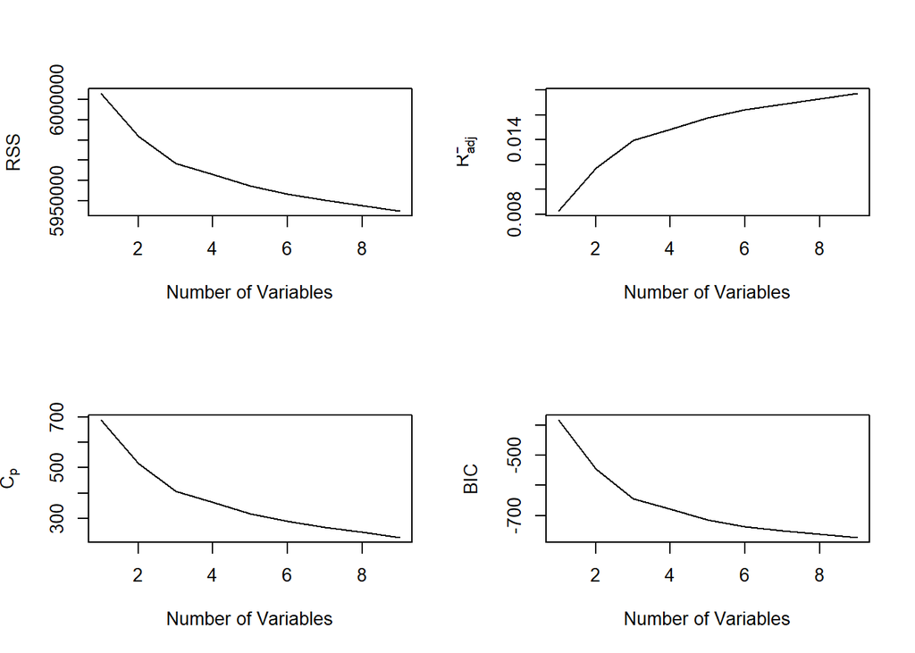

```r
regfit_fwd_a_summary <- summary(regfit_fwd_a)
par(mfrow=c(2,2))
plot(regfit_fwd_a_summary$rss, xlab = "Number of Variables", ylab = "RSS", type = "l")
plot(regfit_fwd_a_summary$adjr2, xlab = "Number of Variables", ylab = expression(R[adj]^2), type="l")
plot(regfit_fwd_a_summary$cp, xlab = "Number of Variables", ylab = expression(C[p]), type= 'l')
plot(regfit_fwd_a_summary$bic, xlab = "Number of Variables", ylab = "BIC", type = 'l')
```

```r
regfit_bwd_a <- regsubsets(y_a ~ ., data = cbind(y_a, x), method = "backward")
```

```
## Reordering variables and trying again:
```

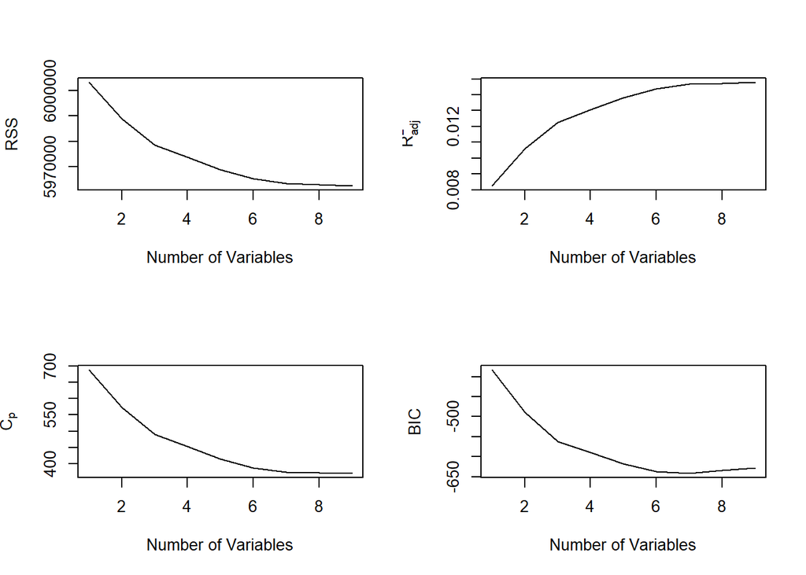

```r
regfit_bwd_a_summary <- summary(regfit_bwd_a)
par(mfrow=c(2,2))
plot(regfit_bwd_a_summary$rss, xlab = "Number of Variables", ylab = "RSS", type = "l")
plot(regfit_bwd_a_summary$adjr2, xlab = "Number of Variables", ylab = expression(R[adj]^2), type="l")
plot(regfit_bwd_a_summary$cp, xlab = "Number of Variables", ylab = expression(C[p]), type= 'l')
plot(regfit_bwd_a_summary$bic, xlab = "Number of Variables", ylab = "BIC", type = 'l')
```

Now, we take a look at the variables included in the best subsets with lowest BIC:

```r
coef(regfit_fwd_a, which.min(regfit_fwd_a_summary$bic))
```

```
##  (Intercept)        naggr      nsgroun       fswata      fsunder       fpdiur
## -2.054765651  1.135783956  0.016929272 -0.005338710 -0.010490546  1.550386833
##       fmbagl       fmstal       fsdump       fcleft
## -0.006649383 -0.023686880 -0.057670782 -0.043321150
```

```r
coef(regfit_bwd_a, which.min(regfit_bwd_a_summary$bic))
```

```
##   (Intercept)         naggr        fswatb        fswata        fstimb
## -0.1866485674  0.8177853648  0.0348063624  0.0008746496 -0.0039014010
##       fsunder        fmbagl        fcleft
## -0.0080259258 -0.0033298289 -0.0621082135
```

```r
regfit_fwd_f <- regsubsets(y_f ~ ., data = cbind(y_f, x), method = "forward")
```

```
## Reordering variables and trying again:
```

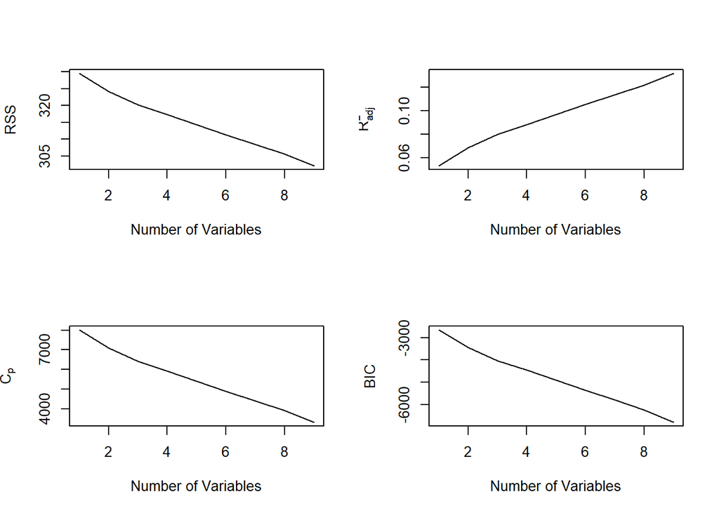

```r
regfit_fwd_f_summary <- summary(regfit_fwd_f)
par(mfrow = c(2, 2))
plot(regfit_fwd_f_summary$rss, xlab = "Number of Variables", ylab = "RSS", type = "l")
plot(regfit_fwd_f_summary$adjr2, xlab = "Number of Variables", ylab = expression(R[adj]^2), type="l")
plot(regfit_fwd_f_summary$cp, xlab = "Number of Variables", ylab = expression(C[p]), type= 'l')
plot(regfit_fwd_f_summary$bic, xlab = "Number of Variables", ylab = "BIC", type = 'l')
```

```r
regfit_bwd_f <- regsubsets(y_f ~ ., data = cbind(y_f, x), method = "backward")
```

```
## Reordering variables and trying again:
```

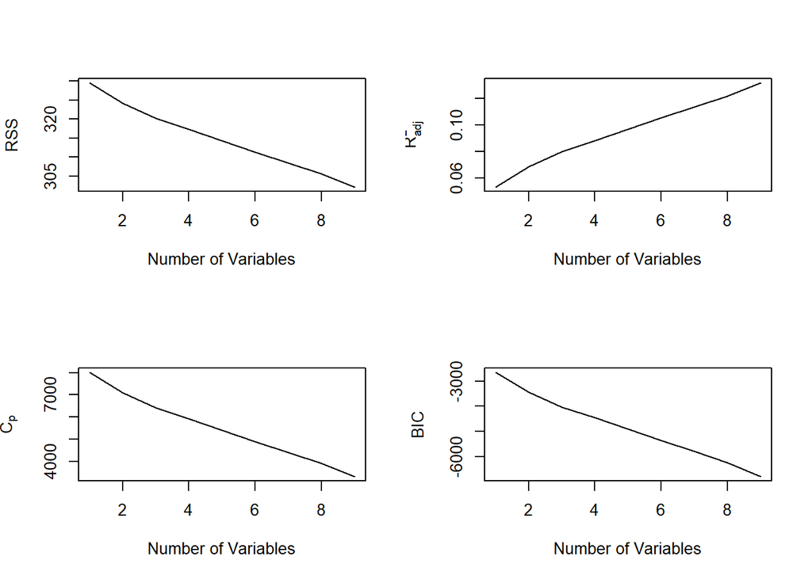

```r
regfit_bwd_f_summary <- summary(regfit_fwd_f)
par(mfrow = c(2, 2))
plot(regfit_bwd_f_summary$rss, xlab = "Number of Variables", ylab = "RSS", type = "l")
plot(regfit_bwd_f_summary$adjr2, xlab = "Number of Variables", ylab = expression(R[adj]^2), type="l")
plot(regfit_bwd_f_summary$cp, xlab = "Number of Variables", ylab = expression(C[p]), type= 'l')
plot(regfit_bwd_f_summary$bic, xlab = "Number of Variables", ylab = "BIC", type = 'l')
```

```r
coef(regfit_fwd_f, which.min(regfit_fwd_f_summary$bic))
```

```
##   (Intercept)         mlife        matage       nsbuild        nscact
##  0.0166385812 -0.0026197634  0.0170635778 -0.0005587623 -0.0049773584
##     fsmidhigh        fpdiur        fcnect        fcseed        fmswoo
## -0.0001688096  0.0062094345 -0.0000740789 -0.0001979096  0.0005304543
```

```r
coef(regfit_bwd_f, which.min(regfit_bwd_f_summary$bic))
```

```
##   (Intercept)        fswatb        fswata        fstimb       fsgroun
## -0.1213328568  0.0013595362  0.0013418077  0.0013601106  0.0013401502
##       fsunder     fsmidhigh      fscanopy      fsaerial        fpnoct
##  0.0008652872  0.0013793398  0.0014240147  0.0013015274  0.0349660770
```

In the case of changes in species frequency, the results of forward and backward subset selection are inconclusive. The only traits that are selected by both approach is feeding in middle to high parts of trees. The increase of $R^2_{adj}$ and decrease of RSS, BIC, and $C_p$ with number of variables in a subset seem monotonic, which suggests that the selected subset is doubtfully better than any other.

### 3.1.6 Regression tree

All previous methods were only used with predictors representing those traits that can be quantified as a continuous variable. Yet, there are some traits that can only be coded as a factor variable (e.g., breeding system is either cooperative, lekking, monogamous, polyandrous, polygamous, polygynous, or promiscuous, and so on; see Table 6.1):

```r
levels(traits$brsys %>% as.factor())
```

```
## [1] "coop"    "lek"     "monog"   "polyand" "polygam" "polygyn" "promisc"
```

```r
levels(traits$dev %>% as.factor())
```

```
## [1] "alt"      "pre2"     "pre3"     "pre4"     "semialt1" "semialt2" "semipre"
```

```r
levels(traits$fc_categ %>% as.factor())
```

```
## [1] "FruiNect"     "Invertebrate" "Omnivore"     "PlantSeed"    "VertFishScav"
```

```r
levels(traits$nest %>% as.factor())
```

```
##  [1] "burrow"   "cavity"   "chamber"  "crevice"  "cup"      "gourd"
##  [7] "no"       "oven"     "paras"    "pend"     "platform" "saucer"
## [13] "scrape"   "sphere"
```

Unlike the methods already considered earlier, decision trees are suitable for incorporating such variables.

```r
x_full <- urb_brds_train[,c("hwi", "mlife", "adsurviv", "matage", "parasi", "egglow", "eggupp",
                 "suces", "attem", "bmass", "naggr", "ndepen",
                 "nsbank", "nsgroun", "nsgrass", "nsclif", "nsbuild", "nsshru",
                 "nsdeci", "nsconi", "nssnag", "nscact", "nstang", "nsfloat",
                 "fsmud", "fswatb", "fswata", "fstimb", "fsgroun", "fsunder",
                 "fsmidhigh", "fscanopy", "fsaerial", "fsdump",
                 "fpnoct", "fpdiur", "klepto",
                 "fcinvert", "fcvend", "fcvect", "fcfish", "fcunk", "fcscav", "fcfruit",
                 "fcnect", "fcseed", "fcgree", "fcleft",
                 "fmdig", "fmgrgl", "fmfogl", "fmbagl", "fmhogl", "fmhopo", "fmhawk", "fmaero", "fmapur",
                 "fmswoo", "fmhipa", "fmlopa", "fmhidi", "fmskim", "fmsdiv", "fmsdip", "fmdabb",
                 "fmstal", "fmprob",
                 "brsys", "dev", "fc_categ", "nest")] %>% as.data.frame()
x_full$brsys <- as.factor(x_full$brsys)
x_full$dev <- as.factor(x_full$dev)
x_full$fc_categ <- as.factor(x_full$fc_categ)
x_full$nest <- as.factor(x_full$nest)
```

First, we will build a tree for change in abundance.

```r
library(tree)
set.seed(1)
tree_a = tree(y_a ~ ., data = cbind(y_a, x_full))
summary(tree_a)
```

```
##
## Regression tree:
## tree(formula = y_a ~ ., data = cbind(y_a, x_full))
## Variables actually used in tree construction:
## character(0)
## Number of terminal nodes:  1
## Residual mean deviance:  124.2 = 6053000 / 48730
## Distribution of residuals:
##      Min.   1st Qu.    Median      Mean   3rd Qu.      Max.
## -954.8000   -1.6370   -0.6372    0.0000    0.0628  501.5000
```

The algorithm could not build a tree for this dataset, suggesting that there are no specific ways the traits could be split to predict changes in species abundance.

Now we switch to difference of species frequency.

```r
set.seed(1)
tree_f = tree(y_f ~ ., data = cbind(y_f, x_full))
summary(tree_f)
```

```
##
## Regression tree:
## tree(formula = y_f ~ ., data = cbind(y_f, x_full))
## Variables actually used in tree construction:
## [1] "attem"    "nscact"   "fc_categ" "mlife"    "klepto"   "nest"     "eggupp"
## Number of terminal nodes:  9
## Residual mean deviance:  0.005501 = 268 / 48720
## Distribution of residuals:
##      Min.   1st Qu.    Median      Mean   3rd Qu.      Max.
## -0.553400 -0.036080  0.001591  0.000000  0.028330  0.779900
```

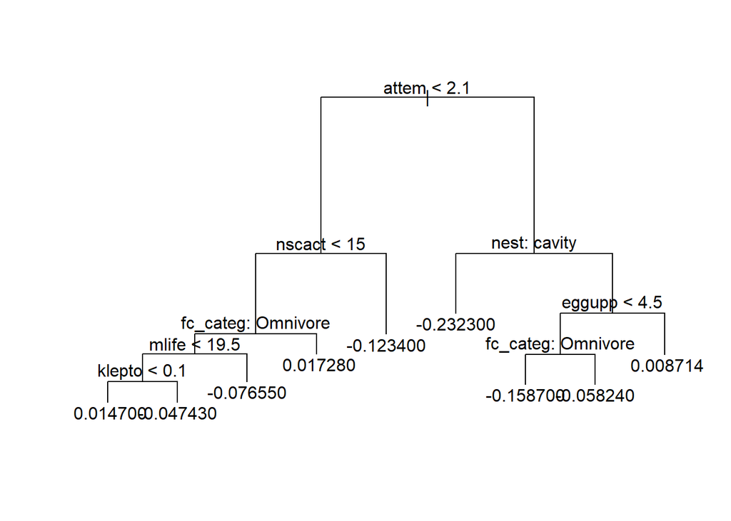

```r
plot(tree_f)
text(tree_f, pretty = 0)
```

Although this model was fed 71 predictor variables, the predictions on median change in frequency can be based on only several traits: number of breeding attempts per year, nest type, nest substrate (cacti), whether a species is an omnivore, a kleptoparasite, number of eggs laid, and maximum life longevity. Pruning the tree is not expected to improve the performance:

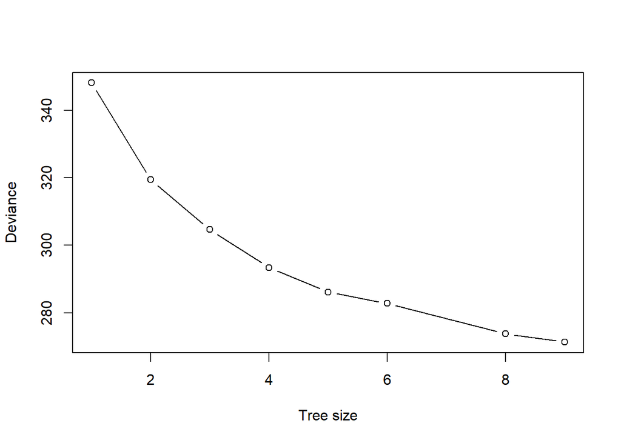

```r
cv_tree_f <- cv.tree(tree_f)
plot(cv_tree_f$size, cv_tree_f$dev, type = 'b', xlab = "Tree size", ylab = "Deviance")
```

### 3.1.7 Comparison of the models

Now, having the following list of models:

- `llm_a`, `llm_f`: Lasso regression with formula `y_a ~ x` and `y_f ~ x`, respectively,
- `pcr_a`, `pcr_f`: PCR regression with formula `y_a ~ x` and `y_f ~ x`, respectively,
- `pls_a`, `pls_f`: PLS regression with formula `y_a ~ x` and `y_f ~ x`, respectively,
- `logit_a`, `logit_f`: logistic regression with formula `logit(y_a > 0) ~ x` and `logit(y_f > 0) ~ x`, respectively,
- `regfit_fwd_a`, `regfit_bwd_a`, `regfit_fwd_f`, `regfit_bwd_f`: multivariate regression with subsets of predictors selected via forward (`*_fwd_*`) and backward (`*_bwd_*`) selection algorithm,
- `tree_f`: regression tree with formula `y_f ~ x_full`,

we can compare the prediction capabilities of them using the test part of the dataset, `urb_brds_test`. We should keep in mind, however, that for the models to be comparable in terms of their error rates, the response should be the same, which is not the case for `logit_*` and `tree_f`, so that these models should be considered separately.

```r
test_x <- urb_brds_test[,c("hwi", "mlife", "adsurviv", "matage", "parasi", "egglow", "eggupp",
                 "suces", "attem", "bmass", "naggr", "ndepen",
                 "nsbank", "nsgroun", "nsgrass", "nsclif", "nsbuild", "nsshru",
                 "nsdeci", "nsconi", "nssnag", "nscact", "nstang", "nsfloat",
                 "fsmud", "fswatb", "fswata", "fstimb", "fsgroun", "fsunder",
                 "fsmidhigh", "fscanopy", "fsaerial", "fsdump",
                 "fpnoct", "fpdiur", "klepto",
                 "fcinvert", "fcvend", "fcvect", "fcfish", "fcunk", "fcscav", "fcfruit",
                 "fcnect", "fcseed", "fcgree", "fcleft",
                 "fmdig", "fmgrgl", "fmfogl", "fmbagl", "fmhogl", "fmhopo", "fmhawk", "fmaero", "fmapur",
                 "fmswoo", "fmhipa", "fmlopa", "fmhidi", "fmskim", "fmsdiv", "fmsdip", "fmdabb",
                 "fmstal", "fmprob")] %>% as.data.frame()
test_x_full <- urb_brds_test[,c("hwi", "mlife", "adsurviv", "matage", "parasi", "egglow", "eggupp",
                 "suces", "attem", "bmass", "naggr", "ndepen",
                 "nsbank", "nsgroun", "nsgrass", "nsclif", "nsbuild", "nsshru",
                 "nsdeci", "nsconi", "nssnag", "nscact", "nstang", "nsfloat",
                 "fsmud", "fswatb", "fswata", "fstimb", "fsgroun", "fsunder",
                 "fsmidhigh", "fscanopy", "fsaerial", "fsdump",
                 "fpnoct", "fpdiur", "klepto",
                 "fcinvert", "fcvend", "fcvect", "fcfish", "fcunk", "fcscav", "fcfruit",
                 "fcnect", "fcseed", "fcgree", "fcleft",
                 "fmdig", "fmgrgl", "fmfogl", "fmbagl", "fmhogl", "fmhopo", "fmhawk", "fmaero", "fmapur",
                 "fmswoo", "fmhipa", "fmlopa", "fmhidi", "fmskim", "fmsdiv", "fmsdip", "fmdabb",
                 "fmstal", "fmprob",
                 "brsys", "dev", "fc_categ", "nest")] %>% as.data.frame()
test_x_full$brsys <- as.factor(test_x_full$brsys)
test_x_full$dev <- as.factor(test_x_full$dev)
test_x_full$fc_categ <- as.factor(test_x_full$fc_categ)
test_x_full$nest <- as.factor(test_x_full$nest)
y_a_test <- urb_brds_train$dif_abundance %>% unlist()
y_f_test <- urb_brds_train$dif_freq %>% unlist()
```

```r
predict_regsubset <- function(reg, x){
  coefs <- coef(reg, which.min(summary(reg)$bic))
  x <- as.matrix(cbind(`(Intercept)` = 1, x))
  x[, names(coefs)] %*% coefs
}
regression_predictions <- tibble(
  y_llm_a = predict(llm_a, newx = test_x %>% as.matrix()) %>% unlist(),
  y_llm_f = predict(llm_f, newx = test_x %>% as.matrix()) %>% unlist(),
  y_pcr_a = predict(pcr_a, test_x %>% as.matrix(), ncomp = pcr_a$ncomp) %>% unlist(),
  y_pcr_f = predict(pcr_f, test_x %>% as.matrix(), ncomp = pcr_f$ncomp) %>% unlist(),
  y_pls_a = predict(pls_a, test_x %>% as.matrix(), ncomp = pls_a$ncomp) %>% unlist(),
  y_pls_f = predict(pls_f, test_x %>% as.matrix(), ncomp = pls_f$ncomp) %>% unlist(),
  y_regfit_fwd_a = predict_regsubset(regfit_fwd_a, test_x) %>% unlist(),
  y_regfit_bwd_a = predict_regsubset(regfit_bwd_a, test_x) %>% unlist(),
  y_regfit_fwd_f = predict_regsubset(regfit_fwd_f, test_x) %>% unlist(),
  y_regfit_bwd_f = predict_regsubset(regfit_bwd_f, test_x) %>% unlist()
)
```

Now, we can calculate MSE for the models predicting change in species abundance:

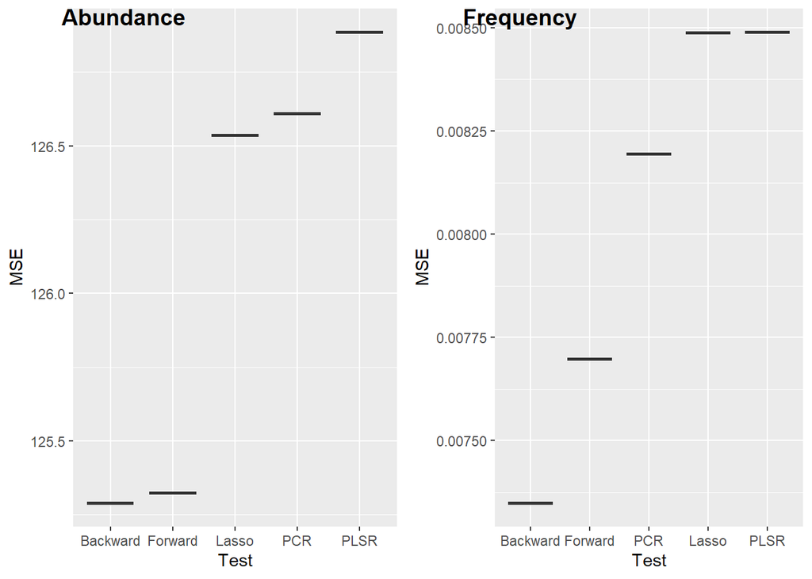

```r
a_modnames <- c("y_llm_a", "y_pcr_a", "y_pls_a", "y_regfit_fwd_a", "y_regfit_bwd_a")
f_modnames <- c("y_llm_f", "y_pcr_f", "y_pls_f", "y_regfit_fwd_f", "y_regfit_bwd_f")
cont_mse_a <- apply((y_a_test - regression_predictions[,a_modnames])^2, 2, mean)
cont_mse_f <- apply((y_f_test - regression_predictions[,f_modnames])^2, 2, mean)
names(cont_mse_a) <- a_modnames
names(cont_mse_f) <- f_modnames
ggarrange(plotlist = list(
  tibble(test = c("Lasso", "PCR", "PLSR", "Forward", "Backward"),
         mse = cont_mse_a) %>%
    arrange(mse) %>%
    ggplot(aes(x = reorder(test, mse), y = mse))+
    geom_boxplot()+
    labs(x = "Test", y = "MSE"),
  tibble(test = c("Lasso", "PCR", "PLSR", "Forward", "Backward"),
         mse = cont_mse_f) %>%
    arrange(mse) %>%
    ggplot(aes(x = reorder(test, mse), y = mse))+
    geom_boxplot()+
    labs(x = "Test", y = "MSE")),
  ncol = 2, nrow = 1, labels = c("Abundance", "Frequency")
)
```

In both cases, a simple multivariate linear regression with subset of predictors selected using backward selection performed the best predicting changes of abundance and frequency of species between non-urban and urban environments.

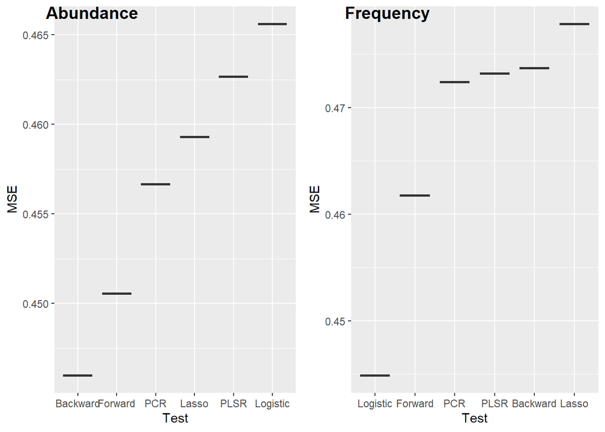

```r
logit_regression_predictions <- regression_predictions %>%
  mutate_all(function(x) x > 0) %>%
  bind_cols(tibble(
    y_logit_a = (predict(logit_a, test_x, type = "response") > 0.5),
    y_logit_f = (predict(logit_f, test_x, type = "response") > 0.5)
  ))
logit_a_modnames <- c("y_llm_a", "y_pcr_a", "y_pls_a", "y_regfit_fwd_a", "y_regfit_bwd_a", "y_logit_a")
logit_f_modnames <- c("y_llm_f", "y_pcr_f", "y_pls_f", "y_regfit_fwd_f", "y_regfit_bwd_f", "y_logit_f")
logit_mse_a <- apply(((y_a_test > 0) - logit_regression_predictions[,logit_a_modnames])^2, 2, mean)
logit_mse_f <- apply(((y_f_test > 0) - logit_regression_predictions[,logit_f_modnames])^2, 2, mean)
names(logit_mse_a) <- logit_a_modnames
names(logit_mse_f) <- logit_f_modnames
ggarrange(plotlist = list(
  tibble(test = c("Lasso", "PCR", "PLSR", "Forward", "Backward", "Logistic"),
         mse = logit_mse_a) %>%
    arrange(mse) %>%
    ggplot(aes(x = reorder(test, mse), y = mse))+
    geom_boxplot()+
    labs(x = "Test", y = "MSE"),
  tibble(test = c("Lasso", "PCR", "PLSR", "Forward", "Backward", "Logistic"),
         mse = logit_mse_f) %>%
    arrange(mse) %>%
    ggplot(aes(x = reorder(test, mse), y = mse))+
    geom_boxplot()+
    labs(x = "Test", y = "MSE")),
  ncol = 2, nrow = 1, labels = c("Abundance", "Frequency")
)
```

If the response variables are considered as a binary response (i.e., if a change of species abundance or frequency larger or smaller than zero), backward subset selection still yields the most accurate prediction, but logistic regression might be a better option to predict whether a species frequency will change in urban patches based on its traits. In both cases the prediction accuracy is only slightly different from random (i.e., 0.5).

## 3.2 Modeling species statuses with unsupervised learning

The poor performance of the models in the previous section can be explained by the fact that data preparation steps were primarily designed to build a model that predicts a discrete status of species relative to its reaction to urbanization (e.g., urban dwellers that only exist in urban habitats, urban avoiders that never colonize urban habitats from surrounding natural areas, or adapters that occur in both types of habitats). This section is dedicated to such predictions.

### 3.2.1 K-Nearest neighbors classification

The data on predictors is already ready for analysis, so it only needs to be plugged into a model. Yet, first we need to pick the optimal $K$ value. Unfortunately, `class:knn` works very slowly for large datasets, so other libraries should be used and the training dataset size should be reduced. Also, all factor variables should be transformed into sets of dummy variables.

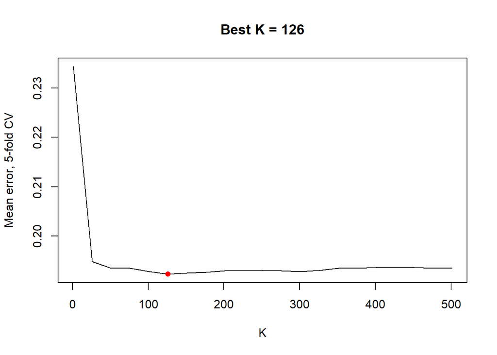

```r
# library(devtools)
# install_github("davpinto/fastknn")
library(fastknn)
set.seed(1)
x_knn <- cbind(x,
               model.matrix( ~ brsys - 1, data = x_full),
               model.matrix( ~ dev - 1, data = x_full),
               model.matrix( ~ fc_categ - 1, data = x_full),
               model.matrix( ~ nest - 1, data = x_full))
y_knn <- as.factor(urb_brds_train$status %>% unlist())
shrink_knn <- sample(1:nrow(x_knn), 5000, F)
x_knn_sub <- x_knn[shrink_knn,]
y_knn_sub <- y_knn[shrink_knn]
knn_cv <- fastknnCV(x = as.matrix(x_knn_sub), y = y_knn_sub,
                    k = seq(1, 501, 25), folds = 5, method = "dist", eval.metric = "mean_error",
                    normalize = "std")
plot(knn_cv$cv_table$k, knn_cv$cv_table$mean, type = "l",
     main = paste("Best K =", knn_cv$cv_table$k[which(knn_cv$cv_table$mean == min(knn_cv$cv_table$mean))]),
     xlab = "K", ylab = "Mean error, 5-fold CV")
points(knn_cv$cv_table$k[which(knn_cv$cv_table$mean == min(knn_cv$cv_table$mean))], min(knn_cv$cv_table$mean), col = "red", pch = 16)
```

Now, a KNN classifier with $K = 125$ will be tested on the entire dataset:

```r
set.seed(1)
x_test_knn <- cbind(test_x,
               model.matrix( ~ brsys - 1, data = test_x_full),
               model.matrix( ~ dev - 1, data = test_x_full),
               model.matrix( ~ fc_categ - 1, data = test_x_full),
               model.matrix( ~ nest - 1, data = test_x_full))
knn_status <- fastknn(xtr = x_knn %>% as.matrix(), ytr = y_knn,
                      xte = x_test_knn[, colnames(x_test_knn) %in% colnames(x_knn)] %>% as.matrix(),
        k = 125, normalize = "std", method = "dist")
table(knn_status$class, urb_brds_test$status %>% as.factor())
```

```
##
##         0     1     2
##   0  9751  2843  3142
##   1  4113 24202  2293
##   2   856   412  1138
```

```r
mean(knn_status$class == urb_brds_test$status %>% as.factor())
```

```
## [1] 0.7198154
```

For a sake of experiment and to validate the results of the previous section, I will run the model again, but using only those traits that were selected as important for environmental filtering.

```r
set.seed(1)
x_knn_lim <- x_knn[, c("fcleft", "fmbagl", "fstimb", "fsunder", "fswata", "fswatb", "naggr",
                       "adsurviv", "bmass", "egglow", "fcgree", "fcinvert", "fcvend", "fmaero",
                       "fmapur", "fmdabb", "fmdig", "fmgrgl", "fmhawk", "fmhidi", "fmhipa", "fmsdip", "fmsdiv",
                       "fmskim", "fmstal", "fpdiur", "hwi", "klepto", "matage", "mlife", "nsbank",
                       "nsbuild", "nscact", "nsdeci", "nsgrass", "nsgroun", "nsshru", "nssnag", "nstang", "parasi")]
knn_status_lim <- fastknn(xtr = x_knn_lim %>% as.matrix(), ytr = y_knn,
                      xte = x_test_knn[, colnames(x_test_knn) %in% colnames(x_knn_lim)] %>% as.matrix(),
        k = 125, normalize = "std", method = "dist")
table(knn_status_lim$class, urb_brds_test$status %>% as.factor())
mean(knn_status_lim$class == urb_brds_test$status %>% as.factor())
```

[output not shown]

### 3.2.2 Linear discriminant analysis

```r
library(MASS)
lda_fit <- lda(y_knn ~ ., data = cbind(y_knn, scale(x_knn)) %>% as.data.frame())
lda_pred <- predict(lda_fit, scale(x_test_knn) %>% as.data.frame())
table(lda_pred$class, urb_brds_test$status %>% as.factor())
```

```
##
##         0     1     2
##   1  8094  3084  2812
##   2  5899 23810  2921
##   3   727   563   840
```

```r
mean(lda_pred$class == (urb_brds_test$status+1) %>% as.factor())
```

```
## [1] 0.6716718
```

LDA predictions are less accurate than KNN, probably, because there is no tuning parameter that can be changed to improve performance.

### 3.2.3 Naїve Bayes classifier

```r
library(e1071)
nb_fit <- naiveBayes(as.factor(y_knn) ~ ., data = cbind(y_knn, scale(x_knn)) %>% as.data.frame())
nb_pred <- predict(nb_fit, x_test_knn)
table(nb_pred, urb_brds_test$status %>% as.factor())
```

```
##
## nb_pred     0     1     2
##       1  5840  9638  2571
##       2  3332  5506  1396
##       3  5548 12313  2606
```

```r
mean(nb_pred == (urb_brds_test$status+1) %>% as.factor())
```

```
## [1] 0.2861949
```

Unfortunately, Naive Bayes performs much less accurate than random predictions.

### 3.2.4 Decision tree

```r
set.seed(1)
tree_status = tree(y_knn ~ ., data = cbind(y_knn, x_full))
summary(tree_status)
```

```
##
## Classification tree:
## tree(formula = y_knn ~ ., data = cbind(y_knn, x_full))
## Variables actually used in tree construction:
## [1] "fcleft"  "nsbuild" "dev"     "naggr"   "hwi"     "attem"   "mlife"
## [8] "fsunder"
## Number of terminal nodes:  10
## Residual mean deviance:  1.62 = 78920 / 48720
## Misclassification error rate: 0.3849 = 18758 / 48733
```

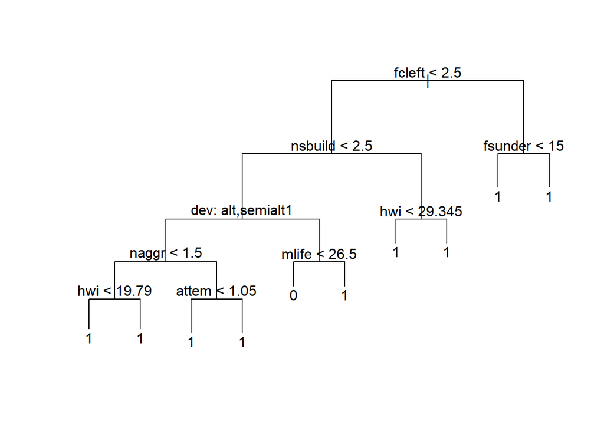

```r
plot(tree_status)
text(tree_status, pretty = 0)
```

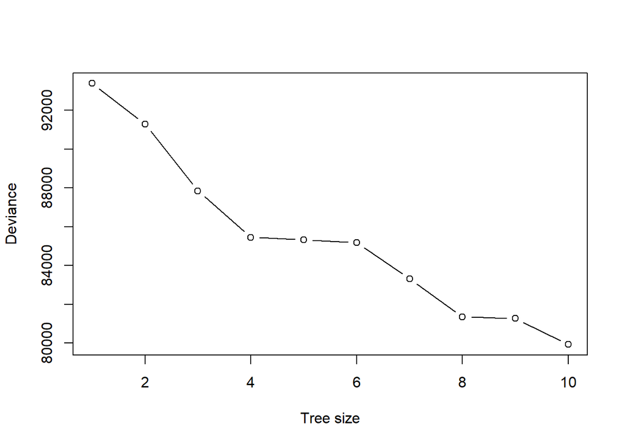

```r
cv_tree_status <- cv.tree(tree_status)
plot(cv_tree_status$size, cv_tree_status$dev, type = 'b', xlab = "Tree size", ylab = "Deviance")
```

With a misclassification rate of 0.39, the accuracy of the tree is $1 - 0.385 = 62\%$.

### 3.2.5 Random forest

Random forest might seem to be the most suitable method for the purpose of this project: not only it is expected to yield accurate predictions for the test data with small variance, but also, as a result of the bootstrap approach, can estimate the relative importance of separate predictors assessing the change of model’s explanatory power when the predictor is ignored.

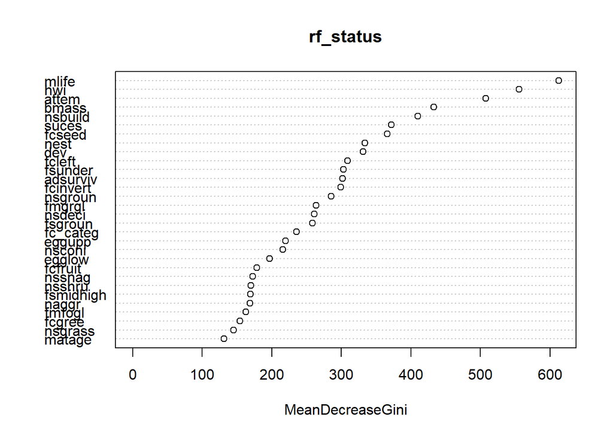

```r
set.seed(1)
rf_status <- randomForest(y_knn ~ ., data = cbind(y_knn, x_full))
varImpPlot(rf_status)
```

The trait predictors that affect a change in Gini index the most when excluded from the tree correspond to life expectancy, wing morphology, number of nesting attempts per year, biomass, building nests on artificial structures, nesting success, feeding on seeds, type of nest, and development at hatching. It is a question, though, how accurate that model can be in predictions.

```r
rf_status$confusion
```

```
##       0     1    2 class.error
## 0 10084  3772  962   0.3194763
## 1  3207 23627  453   0.1341298
## 2  3318  2155 1155   0.8257393
```

This model, again, mostly fails to predict whether a species will have the status “2” (occurring only in cities) based on its traits. However, the model succeeds greatly when predicting statuses “0” and “1”, with the overall accuracy of

```r
mean(predict(rf_status, urb_brds_test[, (colnames(urb_brds_test) %in% colnames(x_full))] %>%
               filter(nest != "chamber") %>%
               mutate(brsys = as.factor(brsys), dev = as.factor(dev),
                      fc_categ = as.factor(fc_categ), nest = as.factor(nest)) %>%
               as.data.frame()) == (urb_brds_test$status %>% unlist()))
```

```
## [1] 0.5232615
```

when used to predict the new data. Unfortunately, this accuracy level is lower than KNN classifier.

# 4 Final Models

When attempting to predict the status of a bird species regarding its traits, the accuracy of predictions seem to be dependent on question. Predicting whether a species only occurs in urban habitats (status “2”) is the most challenging facet of all models built, as such species commonly misclassified as entirely different species, namely as those that only occur in non-urban patches (status “0”) and those that occur in both (status “1”).

A potential way of improving the models’ performance is elimination of the status “2”. For that, I pick the KNN classifier as it showed the best results and random forest that is expected to have low variance. In this model, the tuning parameter is kept at $K = 125$, all variables are standartized to $\mu = 0$ and $\sigma = 1$.

```r
set.seed(1)
stat2_idx <- which(y_knn == "2")
knn_status_01 <- fastknn(xtr = x_knn[-stat2_idx, ] %>% as.matrix(), ytr = y_knn[-stat2_idx],
                      xte = x_test_knn[which(urb_brds_test$status != 2),
                                       colnames(x_test_knn) %in% colnames(x_knn)] %>% as.matrix(),
        k = 125, normalize = "std", method = "dist")
print("Confusion matrix")
```

```
## [1] "Confusion matrix"
```

```r
table((knn_status_01$class %>% as.numeric() - 1), urb_brds_test$status[which(urb_brds_test$status != 2)])
```

```
##
##         0     1
##   0 11114  3803
##   1  3606 23654
```

```r
print("Test eror")
```

```
## [1] "Test eror"
```

```r
mean((knn_status_01$class %>% as.numeric() - 1) == urb_brds_test$status[which(urb_brds_test$status != 2)])
```

```
## [1] 0.8243355
```

Excluding status “2” from the analysis indeed improves the performance of the KNN classifier, increasing its overall accuracy to $82 \%$.

```r
set.seed(1)
y_knn_01 <- y_knn[y_knn != 2] %>% as.character() %>% as.factor()
x_full_01 <- x_full[-stat2_idx, ]
rf_status_01 <- randomForest(y_knn_01 ~ ., data = cbind(y_knn_01, x_full_01))
print("Confusion matrix")
```

```
## [1] "Confusion matrix"
```

```r
rf_status_01$confusion
```

```
##       0     1 class.error
## 0 10876  3942   0.2660278
## 1  3508 23779   0.1285594
```

```r
print("Test eror")
```

```
## [1] "Test eror"
```

```r
trainstat2 <- which(urb_brds_test$status == 2)
mean(predict(rf_status_01, urb_brds_test[, (colnames(urb_brds_test) %in% colnames(x_full))] %>%
               filter(nest != "chamber") %>%
               mutate(brsys = as.factor(brsys), dev = as.factor(dev),
                      fc_categ = as.factor(fc_categ), nest = as.factor(nest)) %>%
               as.data.frame() %>%
               .[-trainstat2,]) == (urb_brds_test[-trainstat2,]$status %>% unlist()))
```

```
## [1] 0.5932617
```

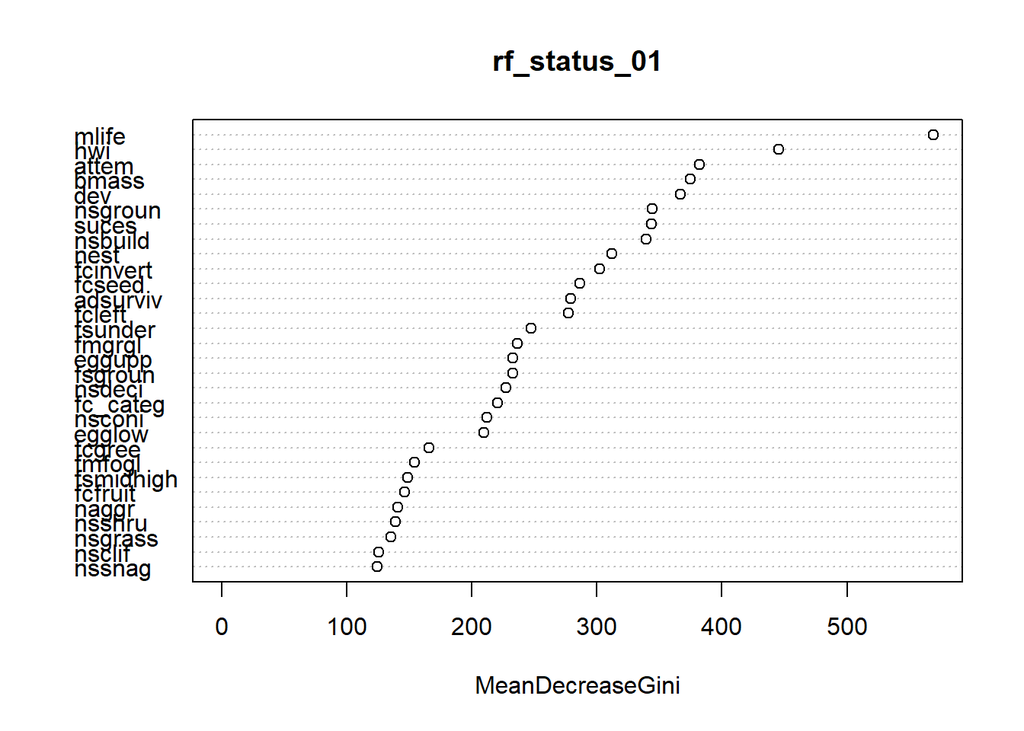

```r
varImpPlot(rf_status_01)
```

Unfortunately, the random forest, although it is handling the training data well, is not as capable of predicting species statuses as the KNN.

To validate the final model chosen from a biological perspective, I will attempt to predict the status of a species for which there is a reasonable expectation for a certain status. For example, the California Condor *Gymnogyps californianus* is a large species that has a distinctive set of traits: this species feeds on carcasses of large mammals, builds nests in rocky dry habitats, sexually matures very lately (6 years) and only produces one egg per two years. With such traits, establishing a population within an urban setting would be nearly impossible, and we can expect that this species will be given status “0”. As this species is only observed in limited set of locations on the West Coast, there is no reason to expect it to occur in Virginia, and the test of the model would answer a question which would never be asked in the real life: “Could the California Condor survive if introduced to a city in Virgina?”

```r
spname2xknn <- function(n){
  sptraits <- traits %>% filter(name == n)
  samecolnames <- colnames(sptraits)[colnames(sptraits) %in% colnames(x_knn)]
  difcolnames <- colnames(x_knn)[!colnames(x_knn) %in% colnames(sptraits)]
  decomposedfactors <- cbind(model.matrix( ~ brsys - 1, data = x_full),
                             model.matrix( ~ dev - 1, data = x_full),
                             model.matrix( ~ fc_categ - 1, data = x_full),
                             model.matrix( ~ nest - 1, data = x_full)) %>% colnames()
  factors <- matrix(rep(0, length(decomposedfactors)), nrow = 1)
  colnames(factors) <- decomposedfactors
  factors <- as_tibble(factors)
  factors[1, paste("brsys", sptraits[,"brsys"] %>% unlist(), sep = "")] <- 1
  factors[1, paste("dev", sptraits[,"dev"] %>% unlist(), sep = "")] <- 1
  factors[1, paste("fc_categ", sptraits[,"fc_categ"] %>% unlist(), sep = "")] <- 1
  factors[1, paste("nest", sptraits[,"nest"] %>% unlist(), sep = "")] <- 1
  out <- bind_cols(sptraits[, samecolnames], factors)
  out[colnames(x_knn)] %>% as.matrix()
}
fastknn(xtr = x_knn[-stat2_idx, ] %>% as.matrix(), ytr = y_knn[-stat2_idx],
                      xte = spname2xknn("Gymnogyps californianus") %>% as.matrix(),
        k = 125, normalize = "std", method = "dist")
```

```
## $class
## [1] 1
## Levels: 0 1 2
##
## $prob
##          0     1 2
## [1,] 0.016 0.984 0
```

Ans, unfortunately, this test did not perform well as the species was classified as exactly the opposite to what we would expect. Another species that is unlikely to be seen in the urban setting is the Wild Turkey *Meleagris gallopavo* which, unlike the Caliofornia Condor, does occur in Virginia.

```r
fastknn(xtr = x_knn[-stat2_idx, ] %>% as.matrix(), ytr = y_knn[-stat2_idx],
                      xte = spname2xknn("Meleagris gallopavo") %>% as.matrix(),
        k = 125, normalize = "std", method = "dist")
```

```
## $class
## [1] 0
## Levels: 0 1 2
##
## $prob
##          0     1 2
## [1,] 0.832 0.168 0
```

Overall, although the primary goal of this work was to develop a model that could predict a status of species relative to its occurrence within and outside of urban patches, it seems that there is a mediocre prediction ability of such a model.

# 5 Discussion

Biologically, rather than building a model, it is more important to address different traits and their role for environmental filtering by urban habitats. For example, one could test the traits selected using the random forest as the ones that affect changes in model performance disproportionately when not considered: `mlife`, `hwi`, `attem`, `bmass`, `nsbuild`, `suces`, `fcseed`, `nest`, and `dev`.

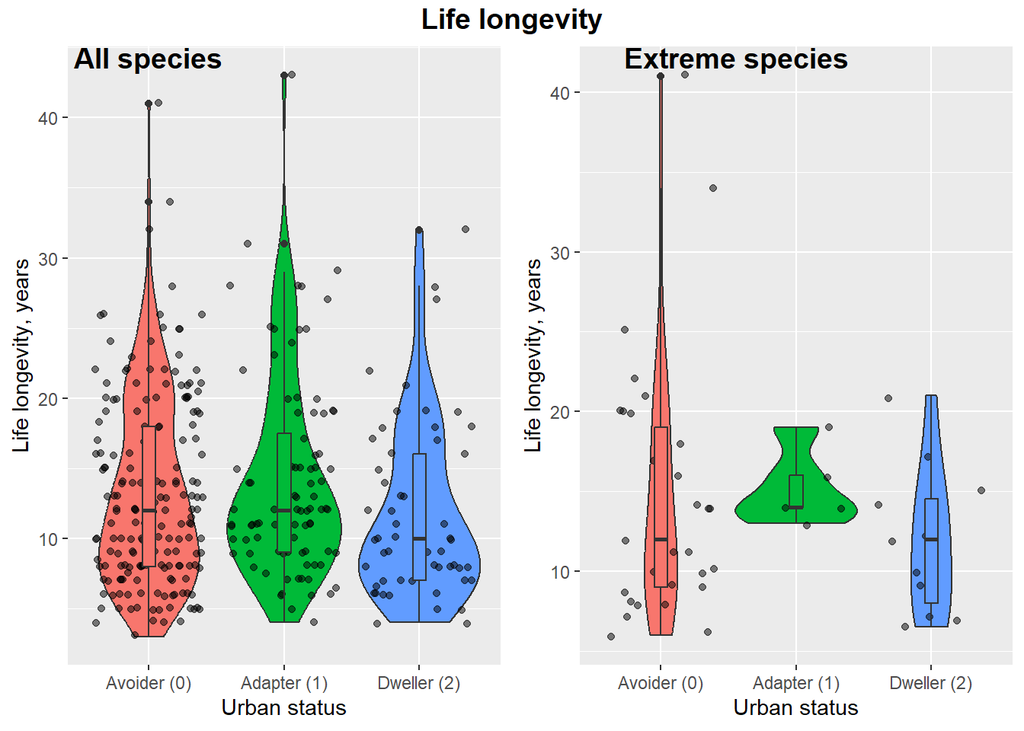

```r
freq <- function(vec, value) length(vec[vec == value])/length(vec)
species_status_freq <- urb_brds %>%
  group_by(name) %>%
  summarise(freq0 = freq(status, 0),
            freq1 = freq(status, 1),
            freq2 = freq(status, 2)) %>%
  left_join(traits, by = "name")
choosemax <- function(var1, var2, var3){
  apply(data.frame(var1, var2, var3), 1, max)
}
species_prevalent_factor <- bind_rows(
  species_status_freq %>% filter(freq0 == choosemax(freq0, freq1, freq2)) %>% mutate(s = "Avoider (0)"),
  species_status_freq %>% filter(freq1 == choosemax(freq0, freq1, freq2)) %>% mutate(s = "Adapter (1)"),
  species_status_freq %>% filter(freq2 == choosemax(freq0, freq1, freq2)) %>% mutate(s = "Dweller (2)")
)
species_extreme_factor <- bind_rows(
  species_status_freq %>% filter(freq0 == 1) %>% mutate(s = "Avoider (0)"),
  species_status_freq %>% filter(freq1 == 1) %>% mutate(s = "Adapter (1)"),
  species_status_freq %>% filter(freq2 == 1) %>% mutate(s = "Dweller (2)")
)

fig_mlife <- ggarrange(
  species_prevalent_factor %>%
    mutate(s = factor(s, levels = c("Avoider (0)", "Adapter (1)", "Dweller (2)"))) %>%
    ggplot(aes(x = s, y = mlife, fill = s))+
    geom_violin()+
    geom_jitter(alpha = 0.5)+
    geom_boxplot(width = 0.1)+
    labs(x = "Urban status", y = "Life longevity, years")+
    theme(legend.position = "none"),
  species_extreme_factor %>%
    mutate(s = factor(s, levels = c("Avoider (0)", "Adapter (1)", "Dweller (2)"))) %>%
    ggplot(aes(x = s, y = mlife, fill = s))+
    geom_violin()+
    geom_jitter(alpha = 0.5)+
    geom_boxplot(width = 0.1)+
    labs(x = "Urban status", y = "Life longevity, years")+
    theme(legend.position = "none"),
  ncol = 2, nrow = 1, labels = c("All species", "Extreme species")
)
annotate_figure(fig_mlife,
                top = text_grob("Life longevity", face = "bold", size = 14))
```

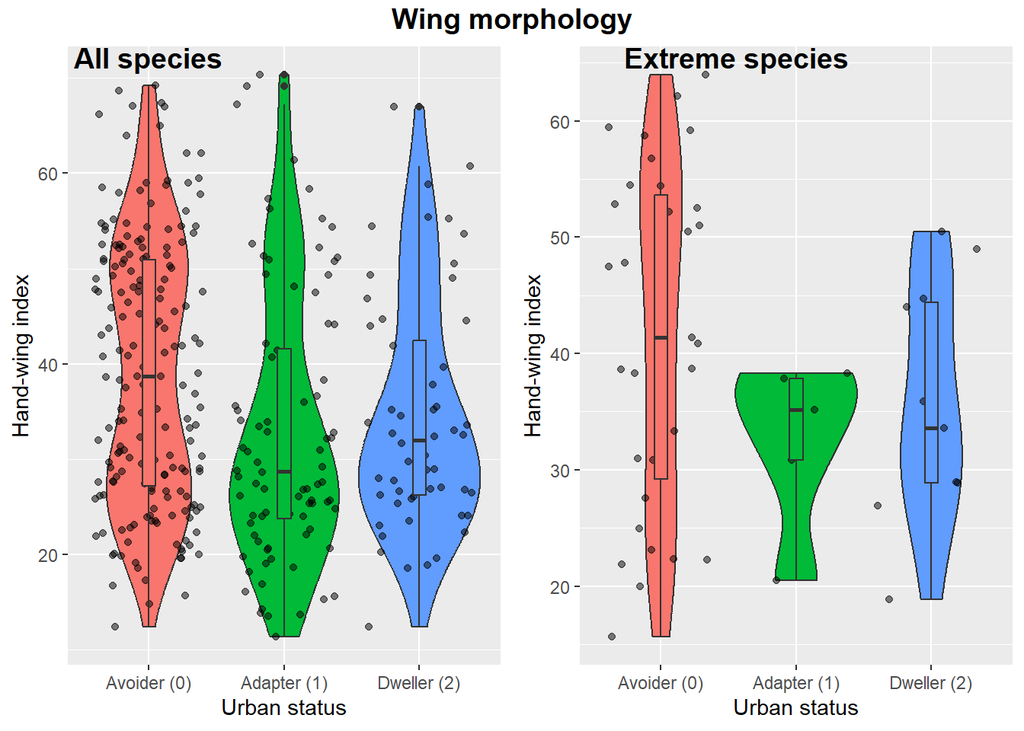

```r
fig_hwi <- ggarrange(
  species_prevalent_factor %>%
    mutate(s = factor(s, levels = c("Avoider (0)", "Adapter (1)", "Dweller (2)"))) %>%
    ggplot(aes(x = s, y = hwi, fill = s))+
    geom_violin()+
    geom_jitter(alpha = 0.5)+
    geom_boxplot(width = 0.1)+
    labs(x = "Urban status", y = "Hand-wing index")+
    theme(legend.position = "none"),
  species_extreme_factor %>%
    mutate(s = factor(s, levels = c("Avoider (0)", "Adapter (1)", "Dweller (2)"))) %>%
    ggplot(aes(x = s, y = hwi, fill = s))+
    geom_violin()+
    geom_jitter(alpha = 0.5)+
    geom_boxplot(width = 0.1)+
    labs(x = "Urban status", y = "Hand-wing index")+
    theme(legend.position = "none"),
  ncol = 2, nrow = 1, labels = c("All species", "Extreme species")
)
annotate_figure(fig_hwi,
                top = text_grob("Wing morphology", face = "bold", size = 14))
```

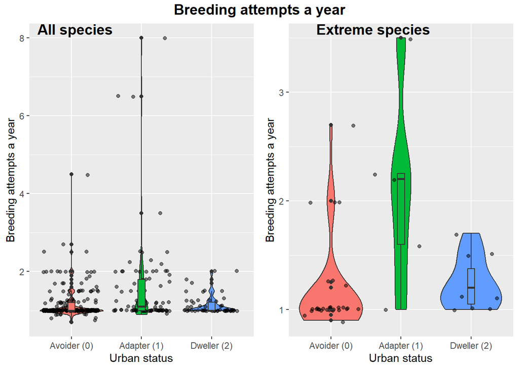

```r
fig_attem <- ggarrange(
  species_prevalent_factor %>%
    mutate(s = factor(s, levels = c("Avoider (0)", "Adapter (1)", "Dweller (2)"))) %>%
    ggplot(aes(x = s, y = attem, fill = s))+
    geom_violin()+
    geom_jitter(alpha = 0.5)+
    geom_boxplot(width = 0.1)+
    labs(x = "Urban status", y = "Breeding attempts a year")+
    theme(legend.position = "none"),
  species_extreme_factor %>%
    mutate(s = factor(s, levels = c("Avoider (0)", "Adapter (1)", "Dweller (2)"))) %>%
    ggplot(aes(x = s, y = attem, fill = s))+
    geom_violin()+
    geom_jitter(alpha = 0.5)+
    geom_boxplot(width = 0.1)+
    labs(x = "Urban status", y = "Breeding attempts a year")+
    theme(legend.position = "none"),
  ncol = 2, nrow = 1, labels = c("All species", "Extreme species")
)
annotate_figure(fig_attem,
                top = text_grob("Breeding attempts a year", face = "bold", size = 14))
```

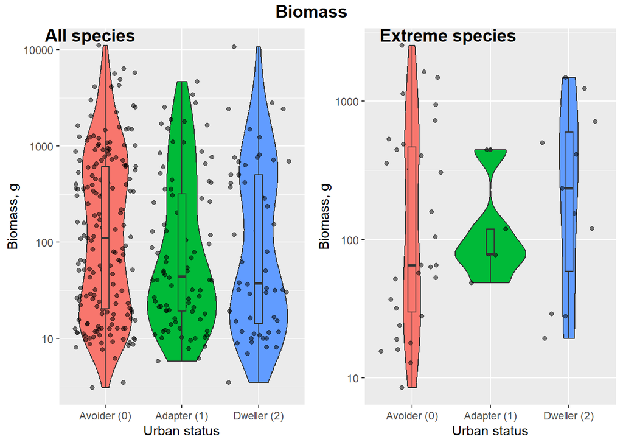

```r
fig_bmass <- ggarrange(
  species_prevalent_factor %>%
    mutate(s = factor(s, levels = c("Avoider (0)", "Adapter (1)", "Dweller (2)"))) %>%
    ggplot(aes(x = s, y = bmass, fill = s))+
    geom_violin()+
    geom_jitter(alpha = 0.5)+
    geom_boxplot(width = 0.1)+
    labs(x = "Urban status", y = "Biomass, g")+
    scale_y_continuous(trans  ="log10")+
    theme(legend.position = "none"),
  species_extreme_factor %>%
    mutate(s = factor(s, levels = c("Avoider (0)", "Adapter (1)", "Dweller (2)"))) %>%
    ggplot(aes(x = s, y = bmass, fill = s))+
    geom_violin()+
    geom_jitter(alpha = 0.5)+
    geom_boxplot(width = 0.1)+
    labs(x = "Urban status", y = "Biomass, g")+
    scale_y_continuous(trans  ="log10")+
    theme(legend.position = "none"),
  ncol = 2, nrow = 1, labels = c("All species", "Extreme species")
)
annotate_figure(fig_bmass,
                top = text_grob("Biomass", face = "bold", size = 14))
```

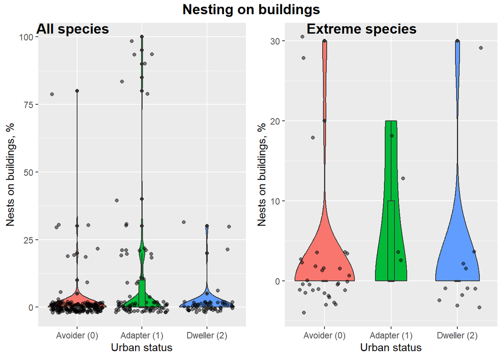

```r
fig_nsbuild <- ggarrange(
  species_prevalent_factor %>%
    mutate(s = factor(s, levels = c("Avoider (0)", "Adapter (1)", "Dweller (2)"))) %>%
    ggplot(aes(x = s, y = nsbuild, fill = s))+
    geom_violin()+
    geom_jitter(alpha = 0.5)+
    geom_boxplot(width = 0.1)+
    labs(x = "Urban status", y = "Nests on buildings, %")+
    theme(legend.position = "none"),
  species_extreme_factor %>%
    mutate(s = factor(s, levels = c("Avoider (0)", "Adapter (1)", "Dweller (2)"))) %>%
    ggplot(aes(x = s, y = nsbuild, fill = s))+
    geom_violin()+
    geom_jitter(alpha = 0.5)+
    geom_boxplot(width = 0.1)+
    labs(x = "Urban status", y = "Nests on buildings, %")+
    theme(legend.position = "none"),
  ncol = 2, nrow = 1, labels = c("All species", "Extreme species")
)
annotate_figure(fig_nsbuild,
                top = text_grob("Nesting on buildings", face = "bold", size = 14))
```

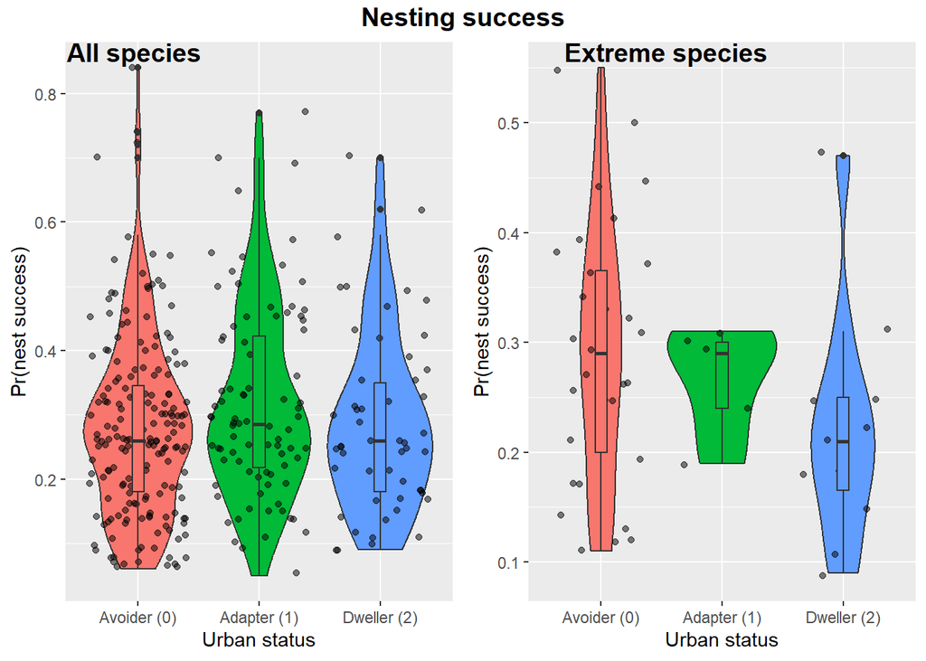

```r
fig_suces <- ggarrange(
  species_prevalent_factor %>%
    mutate(s = factor(s, levels = c("Avoider (0)", "Adapter (1)", "Dweller (2)"))) %>%
    ggplot(aes(x = s, y = suces, fill = s))+
    geom_violin()+
    geom_jitter(alpha = 0.5)+
    geom_boxplot(width = 0.1)+
    labs(x = "Urban status", y = "Pr(nest success)")+
    theme(legend.position = "none"),
  species_extreme_factor %>%
    mutate(s = factor(s, levels = c("Avoider (0)", "Adapter (1)", "Dweller (2)"))) %>%
    ggplot(aes(x = s, y = suces, fill = s))+
    geom_violin()+
    geom_jitter(alpha = 0.5)+
    geom_boxplot(width = 0.1)+
    labs(x = "Urban status", y = "Pr(nest success)")+
    theme(legend.position = "none"),
  ncol = 2, nrow = 1, labels = c("All species", "Extreme species")
)
annotate_figure(fig_suces,
                top = text_grob("Nesting success", face = "bold", size = 14))
```

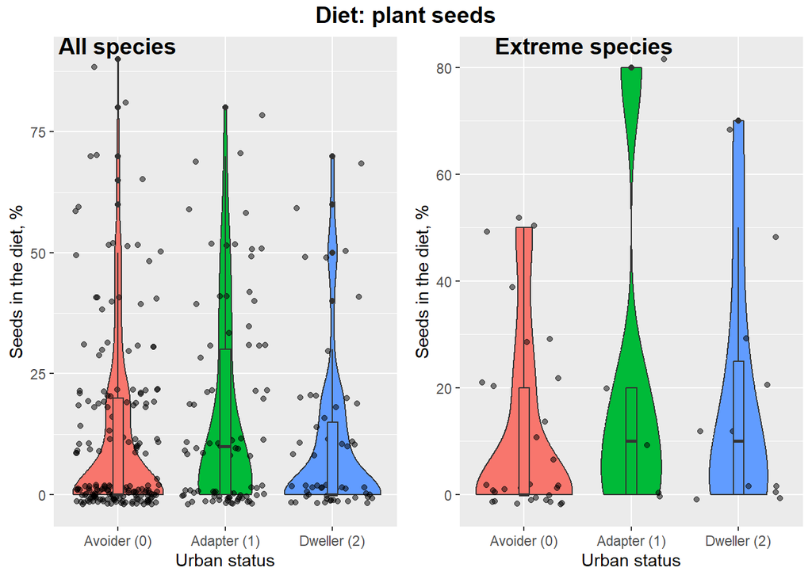

```r
fig_fcseed <- ggarrange(
  species_prevalent_factor %>%
    mutate(s = factor(s, levels = c("Avoider (0)", "Adapter (1)", "Dweller (2)"))) %>%
    ggplot(aes(x = s, y = fcseed, fill = s))+
    geom_violin()+
    geom_jitter(alpha = 0.5)+
    geom_boxplot(width = 0.1)+
    labs(x = "Urban status", y = "Seeds in the diet, %")+
    theme(legend.position = "none"),
  species_extreme_factor %>%
    mutate(s = factor(s, levels = c("Avoider (0)", "Adapter (1)", "Dweller (2)"))) %>%
    ggplot(aes(x = s, y = fcseed, fill = s))+
    geom_violin()+
    geom_jitter(alpha = 0.5)+
    geom_boxplot(width = 0.1)+
    labs(x = "Urban status", y = "Seeds in the diet, %")+
    theme(legend.position = "none"),
  ncol = 2, nrow = 1, labels = c("All species", "Extreme species")
)
annotate_figure(fig_fcseed,
                top = text_grob("Diet: plant seeds", face = "bold", size = 14))
```

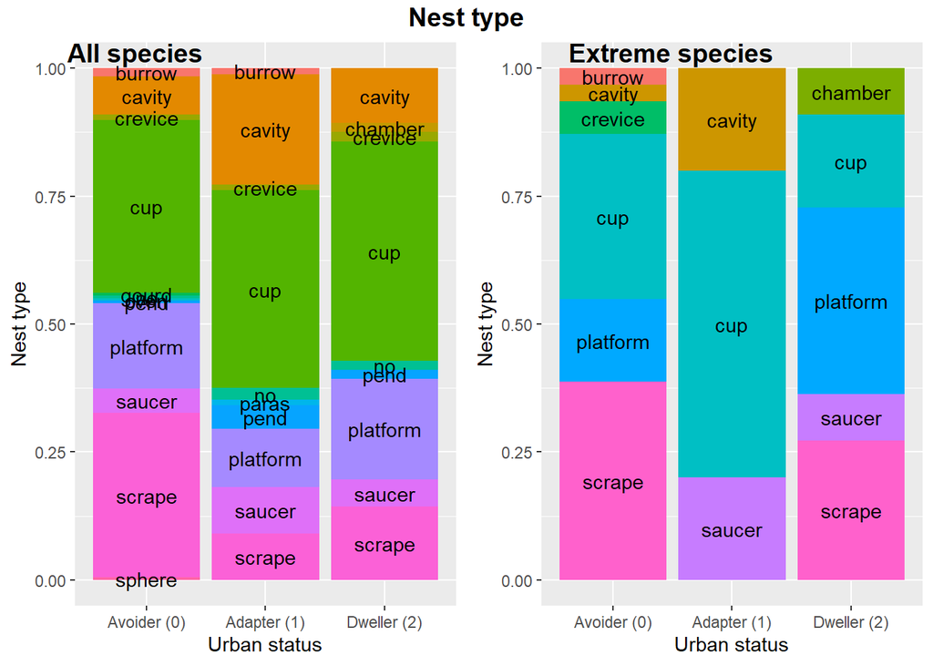

```r
fig_nest <- ggarrange(
  species_prevalent_factor %>%
    mutate(s = factor(s, levels = c("Avoider (0)", "Adapter (1)", "Dweller (2)"))) %>%
    group_by(s, nest) %>%
    summarise(n = n()) %>%
    mutate(prop = n / sum(n)) %>%
    ggplot(aes(x = s, y = prop, fill = nest)) +
    geom_bar(stat = "identity")+
    geom_text(aes(label = nest), position = position_stack(vjust = 0.5)) +
    theme(legend.position = "none")+
    labs(x = "Urban status", y = "Nest type"),
  species_extreme_factor %>%
    mutate(s = factor(s, levels = c("Avoider (0)", "Adapter (1)", "Dweller (2)"))) %>%
    group_by(s, nest) %>%
    summarise(n = n()) %>%
    mutate(prop = n / sum(n)) %>%
    ggplot(aes(x = s, y = prop, fill = nest)) +
    geom_bar(stat = "identity")+
    geom_text(aes(label = nest), position = position_stack(vjust = 0.5)) +
    theme(legend.position = "none")+
    labs(x = "Urban status", y = "Nest type"),
  ncol = 2, nrow = 1, labels = c("All species", "Extreme species")
)
annotate_figure(fig_nest,
                top = text_grob("Nest type", face = "bold", size = 14))
```

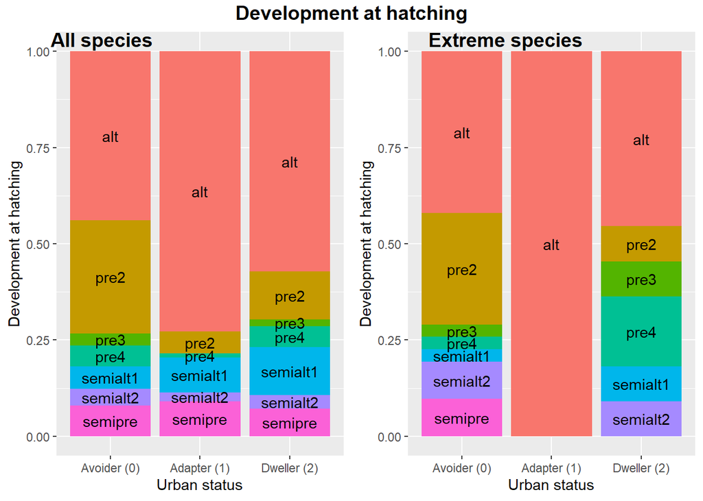

```r
fig_dev <- ggarrange(
  species_prevalent_factor %>%
    mutate(s = factor(s, levels = c("Avoider (0)", "Adapter (1)", "Dweller (2)"))) %>%
    group_by(s, dev) %>%
    summarise(n = n()) %>%
    mutate(prop = n / sum(n)) %>%
    ggplot(aes(x = s, y = prop, fill = dev)) +
    geom_bar(stat = "identity")+
    geom_text(aes(label = dev), position = position_stack(vjust = 0.5)) +
    theme(legend.position = "none")+
    labs(x = "Urban status", y = "Development at hatching"),
  species_extreme_factor %>%
    mutate(s = factor(s, levels = c("Avoider (0)", "Adapter (1)", "Dweller (2)"))) %>%
    group_by(s, dev) %>%
    summarise(n = n()) %>%
    mutate(prop = n / sum(n)) %>%
    ggplot(aes(x = s, y = prop, fill = dev)) +
    geom_bar(stat = "identity")+
    geom_text(aes(label = dev), position = position_stack(vjust = 0.5)) +
    theme(legend.position = "none")+
    labs(x = "Urban status", y = "Development at hatching"),
  ncol = 2, nrow = 1, labels = c("All species", "Extreme species")
)
annotate_figure(fig_dev,
                top = text_grob("Development at hatching", face = "bold", size = 14))
```

The built models cannot be entirely accurate given the approaches taken to prepare the data: it is obvious that some species can have different statuses depending on their abundances (abundant species are more likely to receive status “1” just because they are more likely to be observed in both urban and non-urban settings), locations (there is no reason to believe that a species will always receive the same status in different patches of urban habitats and their partitions), surrounding environments (the binary division into “urban” and “non-urban” environments does not account for the fact that different habitats might have different levels of urbanization), etc.

Looking at trait values of species that are *mostly* classified as belonging to a certain class and species that are *only* classified as such (i.e., extreme urban avoiders, adapters, or dwellers), one could notice that there is high similarity between urban avoiders and dwellers, especially for traits like maximum life longevity, number of breeding attempts per year, contibution of plant seed to species’ diet, nest types, and development at hatching. This similarity might explain why it was so common for all models considered to misclassify species status “2” as “0”.

On the other hand, it is noticeable that urban avoiders have higher than species of other statuses hand-wing index (i.e., long and narrow wings adapted for long flights) and biomass (however, mean biomass of obligate urban dwellers seem to be higher in comparison). Average nesting success of urban adapters seem to be higher, which implies that a reason for their success in different habitats is the reproductive productivity.

There are some caveats to the analysis performed here. First, the data were taken from Virginia only, which limits the extrapolation of the results to other locations within the country and other continents. As we saw on a hypothetical example of the California Condor, the model trained on local fauna of Virginia might provide unreliable results when applied to species from other biogeographical regions. This also implies that if this analysis was to extended at larger spatial scales, biogegraphical regions should necessarily be taken into account.

Second, a closer look should be taken at the traits before building any models. In this project, I attempted to answer two question simultaneously, but some traits are ecologically irrelevant to environmental filtering by urban habitats and only introduce statistical noise to the data. Perhaps, this can be accomplished via a similarity decay analysis (Soininen et al. 2007) where urbanization is treated as a continuous variable and difference in trait values are considered to be a response variable.

It should also be mentioned that some trait variables were not adequately accounted for. Several functional traits are coded as discrete distributions (e.g., `fcinvert`, `fcvend`, `fcvect`, `fcfish`, `fcunk`, `fcscav`, `fcfruit`, `fcnect`, `fcseed`, `fcgree`, `fcleft` will always add up to 100 for each species as they reflect percentage of diet that corresponds to a certain diet item), but were treated as independent variables. This also introduces high multicollinearity in the dataset which makes certain methods (e.g., quadratic discriminant analysis) unusable.

Overall, the K-nearest neighborhoods model could predict species status regarding urban habitats with a certain limited degree of accuracy, however, this model cannot be used to draw conclusions about importance of different traits, for which random forests were used. There are some reasons to conclude that specific bird traits are related to species occurrence within and outside of urban patches in Virginia, but more careful consideration of traits considered is required to confirm a trait-based environmental filtering.

# References

Alig, R. J., J. D. Kline, and M. Lichtenstein. 2004. [Urbanization on the US landscape: Looking ahead in the 21st century](https://doi.org/10.1016/j.landurbplan.2003.07.004). Landscape and Urban Planning 69:219–234.

Antrop, M. 2004. Landscape change and the urbanization process in europe. Landscape and Urban Planning 67:9–26.

Aronson, M. F. J., F. A. L. Sorte, C. H. Nilon, M. Katti, M. A. Goddard, C. A. Lepczyk, P. S. Warren, N. S. G. Williams, S. Cilliers, B. Clarkson, C. Dobbs, R. Dolan, M. Hedblom, S. Klotz, J. L. Kooijmans, I. Kühn, I. MacGregor-Fors, M. McDonnell, U. Mörtberg, P. Pyšek, S. Siebert, J. Sushinsky, P. Werner, and M. Winter. 2014. [A global analysis of the impacts of urbanization on bird and plant diversity reveals key anthropogenic drivers](https://doi.org/10.1098/rspb.2013.3330). Proceedings of the Royal Society B: Biological Sciences 281:20133330.

Bender, D. J., T. A. Contreras, and L. Fahrig. 1998. Habitat loss and population decline: A meta-analysis of the patch size effect. Ecology 79:517–533.

Billerman, S. M., B. K. Keeney, P. G. Rodewald, and T. S. Schulenberg. 2022. [Birds of the world](https://birdsoftheworld.org/bow/home). Cornell Laboratory of Ornithology, Ithaca, New York, USA.

Cadotte, M. W., K. Carscadden, and N. Mirotchnick. 2011. [Beyond species: Functional diversity and the maintenance of ecological processes and services](https://doi.org/10.1111/j.1365-2664.2011.02048.x). Journal of Applied Ecology 48:1079–1087.

Callaghan, C. T., J. E. M. Watson, M. B. Lyons, W. K. Cornwell, and R. A. Fuller. 2021. [Conservation birding: A quantitative conceptual framework for prioritizing citizen science observations](https://doi.org/10.1016/j.biocon.2020.108912). Biological Conservation 253:108912.

Carmona, C. P., F. de Bello, N. W. H. Mason, and J. Lepš. 2016. [Traits without borders: Integrating functional diversity across scales](https://doi.org/10.1016/j.tree.2016.02.003). Trends in Ecology & Evolution 31:382–394.

Clements, J. F., T. S. Schulenberg, M. J. Iliff, T. A. Fredericks, J. A. Gerbracht, D. Lepage, S. M. Billerman, B. L. Sullivan, and C. L. Wood. 2022. [The eBird/clements checklist of birds of the world: v2022](https://www.birds.cornell.edu/clementschecklist/download/). Cornell Laboratory of Ornithology, Ithaca, New York, USA.

Croci, S., A. Butet, and P. Clergeau. 2008. [Does urbanization filter birds on the basis of their biological traits?](https://doi.org/10.1525/cond.2008.8409) The Condor 110:223–240.

Diaz, S., and M. Cabido. 2001. Vive la difference: Plant functional diversity matters to ecosystem processes. Trends in Ecology & Evolution 16:646–655.

Ehrlich, P., D. Dobkin, and D. Wheye. 1988. The birder’s handbook: A field guide to the natural history of north american birds. Prentice Hall & IBD, London, UK.

ESRI. 2022. [ArcGIS pro 3.1.0](https://www.esri.com/en-us/arcgis/products/arcgis-pro/overview). Environmental Systems Research Institute.

Evans, B. S., R. Reitsma, A. H. Hurlbert, and P. P. Marra. 2018. [Environmental filtering of avian communities along a rural‐to‐urban gradient in greater washington, d.c., USA](https://doi.org/10.1002/ecs2.2402). Ecosphere 9:e02402.

Field, A. P. 2005. Discovering statistics using SPSS. SAGE, New Delhi, India.

Friedl, M., and D. Sulla-Menashe. 2022. [MODIS/terra+aqua land cover type yearly L3 global 500m SIN grid V061](https://doi.org/10.5067/MODIS/MCD12Q1.061). NASA EOSDIS Land Processes DAAC.

Guadagnoli, E., and W. F. Velicer. 1988. [Relation of sample size to the stability of component patterns.](https://doi.org/10.1037/0033-2909.103.2.265) Psychological Bulletin 103:265–275.

Johnston, A., W. M. Hochachka, M. E. Strimas-Mackey, V. R. Gutierrez, O. J. Robinson, E. T. Miller, T. Auer, S. T. Kelling, and D. Fink. 2021. [Analytical guidelines to increase the value of community science data: An example using eBird data to estimate species distributions](https://doi.org/10.1111/ddi.13271). Diversity and Distributions 27:1265–1277.

Keddy, P. A. 1992. [Assembly and response rules: Two goals for predictive community ecology](https://doi.org/10.2307/3235676). Journal of Vegetation Science 3:157–164.

Kelling, S., A. Johnston, A. Bonn, D. Fink, V. Ruiz-Gutierrez, R. Bonney, M. Fernandez, W. M. Hochachka, R. Julliard, R. Kraemer, and R. Guralnick. 2019. [Using semistructured surveys to improve citizen science data for monitoring biodiversity](https://doi.org/10.1093/biosci/biz010). BioScience 69:170–179.

Laughlin, D. C., J. R. Gremer, P. B. Adler, R. M. Mitchell, and M. M. Moore. 2020. [The net effect of functional traits on fitness](https://doi.org/10.1016/j.tree.2020.07.010). Trends in Ecology & Evolution 35:1037–1047.

McGill, B., B. Enquist, E. Weiher, and M. Westoby. 2006. [Rebuilding community ecology from functional traits](https://doi.org/10.1016/j.tree.2006.02.002). Trends in Ecology & Evolution 21:178–185.

McKinney, M. L. 2002. Urbanization, biodiversity, and conservation. BioScience 52:883.

Mittelbach, G. G., and D. W. Schemske. 2015. [Ecological and evolutionary perspectives on community assembly](https://doi.org/10.1016/j.tree.2015.02.008). Trends in Ecology & Evolution 30:241–247.

Newbold, T., L. N. Hudson, S. L. L. Hill, S. Contu, I. Lysenko, R. A. Senior, L. Börger, D. J. Bennett, A. Choimes, B. Collen, J. Day, A. D. Palma, S. Dı́az, S. Echeverria-Londoño, M. J. Edgar, A. Feldman, M. Garon, M. L. K. Harrison, T. Alhusseini, D. J. Ingram, Y. Itescu, J. Kattge, V. Kemp, L. Kirkpatrick, M. Kleyer, D. L. P. Correia, C. D. Martin, S. Meiri, M. Novosolov, Y. Pan, H. R. P. Phillips, D. W. Purves, A. Robinson, J. Simpson, S. L. Tuck, E. Weiher, H. J. White, R. M. Ewers, G. M. Mace, J. P. W. Scharlemann, and A. Purvis. 2015. [Global effects of land use on local terrestrial biodiversity](https://doi.org/10.1038/nature14324). Nature 520:45–50.

Palacio, F. X., L. M. Ibañez, R. E. Maragliano, and D. Montalti. 2018. [Urbanization as a driver of taxonomic, functional, and phylogenetic diversity losses in bird communities](https://doi.org/10.1139/cjz-2018-0008). Canadian Journal of Zoology 96:1114–1121.

Rodewald, A. D., and R. H. Yahner. 2001. Influence of landscape composition on avian community structure and associated mechanisms. Ecology 82:3493–3504.

Sekercioglu, C. H. 2002. [Impacts of birdwatching on human and avian communities](https://doi.org/10.1017/s0376892902000206). Environmental Conservation 29:282–289.

Sheard, C., M. H. C. Neate-Clegg, N. Alioravainen, S. E. I. Jones, C. Vincent, H. E. A. MacGregor, T. P. Bregman, S. Claramunt, and J. A. Tobias. 2020. [Ecological drivers of global gradients in avian dispersal inferred from wing morphology](https://doi.org/10.1038/s41467-020-16313-6). Nature Communications 11.

Soininen, J., R. McDonald, and H. Hillebrand. 2007. [The distance decay of similarity in ecological communities](https://doi.org/10.1111/j.0906-7590.2007.04817.x). Ecography 30:3–12.

Stevens, J. P. 1992. Applied multivariate statistics for the social sciences. Second edition. Psychology Press, Philadelphia, Pennsylvania, USA.

Strimas-Mackey, M., W. M. Hochachka, V. Ruiz-Gutierrez, O. J. Robinson, E. T. Miller, T. Auer, S. Kelling, D. Fink, and A. Johnston. 2020. [Best practices for using eBird data v1.0](https://doi.org/10.5281/ZENODO.3620739). Cornell Lab of Ornithology.

Taylor, P. D., L. Fahrig, K. Henein, and G. Merriam. 1993. [Connectivity is a vital element of landscape structure](https://doi.org/10.2307/3544927). Oikos 68:571.

Tilman, D., F. Isbell, and J. M. Cowles. 2014. [Biodiversity and ecosystem functioning](https://doi.org/10.1146/annurev-ecolsys-120213-091917). Annual Review of Ecology, Evolution, and Systematics 45:471–493.

Tobias, J. A., C. Sheard, A. L. Pigot, A. J. M. Devenish, J. Yang, F. Sayol, M. H. C. Neate-Clegg, N. Alioravainen, T. L. Weeks, R. A. Barber, P. A. Walkden, H. E. A. MacGregor, S. E. I. Jones, C. Vincent, A. G. Phillips, N. M. Marples, F. A. Montaño-Centellas, V. Leandro-Silva, S. Claramunt, B. Darski, B. G. Freeman, T. P. Bregman, C. R. Cooney, E. C. Hughes, E. J. R. Capp, Z. K. Varley, N. R. Friedman, H. Korntheuer, A. Corrales-Vargas, C. H. Trisos, B. C. Weeks, D. M. Hanz, T. Töpfer, G. A. Bravo, V. Remeš, L. Nowak, L. S. Carneiro, A. J. M. R., B. Matysioková, D. T. Baldassarre, A. Martı́nez-Salinas, J. D. Wolfe, P. M. Chapman, B. G. Daly, M. C. Sorensen, A. Neu, M. A. Ford, R. J. Mayhew, L. F. Silveira, D. J. Kelly, N. N. D. Annorbah, H. S. Pollock, A. M. Grabowska-Zhang, J. P. McEntee, J. C. T. Gonzalez, C. G. Meneses, M. C. Muñoz, L. L. Powell, G. A. Jamie, T. J. Matthews, O. Johnson, G. R. R. Brito, K. Zyskowski, R. Crates, M. G. Harvey, M. J. Zevallos, P. A. Hosner, T. Bradfer-Lawrence, J. M. Maley, F. G. Stiles, H. S. Lima, K. L. Provost, M. Chibesa, M. Mashao, J. T. Howard, E. Mlamba, M. A. H. Chua, B. Li, M. I. Gómez, N. C. Garcı́a, M. Päckert, J. Fuchs, J. R. Ali, E. P. Derryberry, M. L. Carlson, R. C. Urriza, K. E. Brzeski, D. M. Prawiradilaga, M. J. Rayner, E. T. Miller, R. C. K. Bowie, R.-M. Lafontaine, R. P. Scofield, Y. Lou, L. Somarathna, D. Lepage, M. Illif, E. L. Neuschulz, M. Templin, D. M. Dehling, J. C. Cooper, O. S. G. Pauwels, K. Analuddin, J. Fjeldså, N. Seddon, P. R. Sweet, F. A. J. DeClerck, L. N. Naka, J. D. Brawn, A. Aleixo, K. Böhning-Gaese, C. Rahbek, S. A. Fritz, G. H. Thomas, and M. Schleuning. 2022. [AVONET: Morphological, ecological and geographical data for all birds](https://doi.org/10.1111/ele.13898). Ecology Letters 25:581–597.

Whittingham, M. J., P. A. Stephens, R. B. Bradbury, and R. P. Freckleton. 2006. [Why do we still use stepwise modelling in ecology and behaviour?](https://doi.org/10.1111/j.1365-2656.2006.01141.x) Journal of Animal Ecology 75:1182–1189.

Wilman, H., J. Belmaker, J. Simpson, C. de la Rosa, M. M. Rivadeneira, and W. Jetz. 2014. [EltonTraits 1.0: Species-level foraging attributes of the world’s birds and mammals](https://doi.org/10.1890/13-1917.1). Ecology 95:2027–2027.

# 6 Appendix

Table 6.1: Codes and explanations of the functional traits used.

| Trait | Values | Variable | Explanation | Source |
| --- | --- | --- | --- | --- |
| Diet items | % | fcinvert | invertebrates | E, W, B |
| Diet items | % | fcvend | endothermic (warm-blooded) vertebrates | E, W, B |
| Diet items | % | fcvect | cold-blooded vertebrates | E, W, B |
| Diet items | % | fcfish | fish | E, W, B |
| Diet items | % | fcunk | unknown vertebrates | E, W, B |
| Diet items | % | fcscav | carcasses | E, W, B |
| Diet items | % | fcfruit | fruits | E, W, B |
| Diet items | % | fcnect | nectar | E, W, B |
| Diet items | % | fcseed | seeds | E, W, B |
| Diet items | % | fcgree | green parts of plants | E, W, B |
| Diet items | % | fcleft | leftovers | E, W, B |
| Diurnal feeding | binary | fpdiur | is foraging at day? | E |
| Nocturnal feeding | binary | fpnoct | is foraging at night? | E |
| Diet | factor: FruiNect | fc_categ | fruits and nectar | E, W, B |
| Diet | factor: Invertebrate | fc_categ | invertebrates | E, W, B |
| Diet | factor: Omnivore | fc_categ | omnivore | E, W, B |
| Diet | factor: PlantSeed | fc_categ | plants and seeds | E, W, B |
| Diet | factor: VertFishScav | fc_categ | vertebrates or fish or scavenging | E, W, B |
| Feeding method | % | fmdig | digging | E, B |
| Feeding method | % | fmgrgl | ground glean | E, B |
| Feeding method | % | fmfogl | foliage glean | E, B |
| Feeding method | % | fmbagl | bark glean | E, B |
| Feeding method | % | fmhogl | gleaning while hovering | E, B |
| Feeding method | % | fmhopo | hover and pouncing | E, B |
| Feeding method | % | fmhawk | hawking | E, B |
| Feeding method | % | fmaero | aerial foliage | E, B |
| Feeding method | % | fmapur | aerial pursuit | E, B |
| Feeding method | % | fmswoo | swoops | E, B |
| Feeding method | % | fmhipa | high patrol | E, B |
| Feeding method | % | fmlopa | low patrol | E, B |

[output cut: 72 more lines]

[^1]: **ecological community** is a set of populations of different species that occupy the same location at the same time; community ecology relies heavily on mathematical and statistical approaches due to omnipresent statistical noise in the data describing complex multi-species systems
[^2]: **functional trait** is a characteristic of a species or individual that affects its fitness to the environment; in other words, it is a descriptor of a biological organism (i.e., color, body mass, diet, morphometrics etc.)
[^3]: **citizen science** is a scientific research framework which incorporates data collection and analysis conducted by lay citizens
[^4]: free access to the data requires an annual approval from the database management team to be able to either download a subset of the data or the whole dataset at once (>140 GB)
[^5]: the request was submitted and approved on 31 Mar 2023, download raw data [here](https://ebird.org/data/download?p=ebd_US-VA_relFeb-2023.zip), however, the download link might be inactive; prepackaged sampling event data were downloaded for the entire world on 31 Mar 2023
[^6]: i.e., observers indicated that all species that could be identified were reported, so that there is no reason to expect false-absence of species in such observation
[^7]: Mar 15—Jun 15 which covers breeding season of most birds in Virginia
[^8]: taxonomy here denotes the identities of species; as species identities are coded as integers, it is highly important to account for any changes, since otherwise it would cause referring to one species as if it was a different species
[^9]: references are coded as following: Billerman et al. 2022 (B), Ehrlich et al. 1988 (E), Sheard et al. 2020 (S), and Wilman et al. 2014 (W)
[^10]: as per the [MCD12Q1 description](https://developers.google.com/earth-engine/datasets/catalog/MODIS_061_MCD12Q1#bands), pixel value “13” denotes “urban and built-up lands: at least 30% impervious surface area including building materials, asphalt and vehicles”
[^11]: the area of 4 square kilometers constitutes the 5th percentile of urban areas in the U.S. according to the [2019 TIGER/Line Shapefiles data]^(https://www.census.gov/geographies/mapping-files/time-series/geo/tiger-line-file.html)
[^12]: the results are **very** close to the previous model; probably, it can be explained by strong correlation found (see Fig. 2.3) between differences in abundance and frequency
[^13]: I did try to test it with `gvlma`, which did not work due to `Error in solve.default(sigwhat) : system is computationally singular: reciprocal condition number = 3.4205e-45`; from what I found about this error, it cannot even fit the models to check the assumptions due to high multicollinearity
[^14]: the data considered here constitutes a situation where a mixed-effect approach should be used, as every partition of urban patches is a different sampling unit; however, it is very computationally expensive and takes too much time so I did not include `glmer`s into the analyses, yet I left the code commented out